# heatmaps

Rmd to make heatmaps for the crab project. Used normalized counts.

### Set up R Markdown document

## Install/load packages:

(uncomment “install.packages(”pheatmap“)” if you need to install it)

```r
#install.packages("pheatmap")
library(pheatmap)
```

```r
library(dplyr)
#install.packages("RColorBrewer")
library(RColorBrewer)
```

# NEW HEATMAP ATTEMPTS!

Read in normalized counts:

```r
norm_counts <- read.delim("../data/salmon.isoform.TMM.EXPR.matrix")
head(norm_counts)
```

```
##                          X X294_quant X254_quant X280_quant X485_quant
## 1  TRINITY_DN5772_c0_g1_i1      0.000      0.000      0.000      0.000
## 2  TRINITY_DN2201_c0_g1_i1      0.406      0.000      1.537      0.000
## 3  TRINITY_DN4656_c0_g1_i1      2.445      7.675      1.673      3.277
## 4  TRINITY_DN7591_c0_g1_i1      3.369      1.049      1.366      0.444
## 5  TRINITY_DN6285_c0_g1_i4      0.000      0.000      0.000      1.806
## 6 TRINITY_DN28918_c0_g1_i1      0.000      0.000      0.000      0.000
##   X481_quant X173_quant X222_quant X151_quant X272_quant X132_quant X127_quant
## 1      0.000      0.000      0.000      0.000          0       0.00      0.000
## 2      0.000      0.000      0.817      0.000          0       0.00      0.000
## 3      2.057     28.523      2.074      4.561          0       2.39      2.925
## 4      6.289      0.000      4.666      2.383          0       0.00     10.800
## 5      0.000      0.000      0.000      0.000          0       0.00      0.000
## 6      1.520      0.000      0.000      0.000          0       0.00      0.919
##   X73_quant X427_quant X118_quant X334_quant X349_quant X425_quant X178_quant
## 1         0          0      0.000      0.000          0          0      0.000
## 2         0          0      0.000      0.000          0          0      0.000
## 3         0          0      2.047      1.627          0          0      6.384
## 4         0          0      1.650      0.000          0          0      0.839
## 5         0          0      0.000      0.000          0          0      0.000
## 6         0          0      0.000      0.000          0          0      1.990
##   X72_quant X463_quant X221_quant X445_quant X359_quant X113_quant
## 1     0.000          0          0      0.000      1.976      0.000
## 2     0.000          0          0      7.232      0.000      2.599
## 3     2.853          0          0      2.853      4.987      2.019
## 4     0.000          0          0      8.787      5.773      8.427
## 5     0.000          0          0      1.397      0.000      0.000
## 6     0.000          0          0      0.000      0.000      0.000
```

40,035 rows of normalized count data for 24 samples

Rename columns:

```r
colnames(norm_counts) <- c("Trinity_ID", "CrabH_2", "CrabE_2", "CrabI_2", "CrabC_17", "CrabB_17", "CrabG_0", "CrabF_2", "CrabE_0", "CrabG_2", "CrabC_0", "CrabI_0", "CrabD_0", "CrabD_17", "CrabB_0", "CrabC_2", "CrabB_2", "CrabF_17", "CrabA_0", "CrabH_0", "CrabA_17", "CrabD_2", "CrabE_17", "CrabA_2", "CrabF_0")
head(norm_counts)
```

```
##                 Trinity_ID CrabH_2 CrabE_2 CrabI_2 CrabC_17 CrabB_17 CrabG_0
## 1  TRINITY_DN5772_c0_g1_i1   0.000   0.000   0.000    0.000    0.000   0.000
## 2  TRINITY_DN2201_c0_g1_i1   0.406   0.000   1.537    0.000    0.000   0.000
## 3  TRINITY_DN4656_c0_g1_i1   2.445   7.675   1.673    3.277    2.057  28.523
## 4  TRINITY_DN7591_c0_g1_i1   3.369   1.049   1.366    0.444    6.289   0.000
## 5  TRINITY_DN6285_c0_g1_i4   0.000   0.000   0.000    1.806    0.000   0.000
## 6 TRINITY_DN28918_c0_g1_i1   0.000   0.000   0.000    0.000    1.520   0.000
##   CrabF_2 CrabE_0 CrabG_2 CrabC_0 CrabI_0 CrabD_0 CrabD_17 CrabB_0 CrabC_2
## 1   0.000   0.000       0    0.00   0.000       0        0   0.000   0.000
## 2   0.817   0.000       0    0.00   0.000       0        0   0.000   0.000
## 3   2.074   4.561       0    2.39   2.925       0        0   2.047   1.627
## 4   4.666   2.383       0    0.00  10.800       0        0   1.650   0.000
## 5   0.000   0.000       0    0.00   0.000       0        0   0.000   0.000
## 6   0.000   0.000       0    0.00   0.919       0        0   0.000   0.000
##   CrabB_2 CrabF_17 CrabA_0 CrabH_0 CrabA_17 CrabD_2 CrabE_17 CrabA_2 CrabF_0
## 1       0        0   0.000   0.000        0       0    0.000   1.976   0.000
## 2       0        0   0.000   0.000        0       0    7.232   0.000   2.599
## 3       0        0   6.384   2.853        0       0    2.853   4.987   2.019
## 4       0        0   0.839   0.000        0       0    8.787   5.773   8.427
## 5       0        0   0.000   0.000        0       0    1.397   0.000   0.000
## 6       0        0   1.990   0.000        0       0    0.000   0.000   0.000
```

# TEMPERATURE DEGs

## Heatmap of temperature DEG list across all samples

Read in Temperature DEG list (423)

```r
temp_degs <- read.delim("../analyses/DEG-temperature.txt", header = TRUE)
head(temp_degs)
```

```
##                 Trinity_ID   baseMean log2FoldChange     lfcSE      stat
## 1     TRINITY_DN1_c0_g1_i3  1527.9064     -0.9307566 0.1596984 -5.828216
## 2 TRINITY_DN10098_c0_g1_i2   427.5377     -0.9505347 0.2437734 -3.899255
## 3  TRINITY_DN1016_c0_g1_i1   157.8117     -2.1808200 0.4256654 -5.123320
## 4  TRINITY_DN1020_c0_g1_i1   588.7443      1.3741964 0.3815273  3.601830
## 5 TRINITY_DN10318_c0_g1_i1  1579.3697     -0.5605904 0.1662810 -3.371344
## 6  TRINITY_DN1050_c0_g1_i1 44107.5277     -0.4868810 0.1625710 -2.994882
##         pvalue        padj
## 1 0.0000000056 0.000001400
## 2 0.0000965000 0.004582470
## 3 0.0000003000 0.000036700
## 4 0.0003159850 0.009601251
## 5 0.0007480240 0.017622738
## 6 0.0027455140 0.042490214
```

`join` with norm_counts by “Trinity_ID”

```r
temp_degs_counts <- left_join(norm_counts, temp_degs, by = "Trinity_ID")
head(temp_degs_counts)
```

```
##                 Trinity_ID CrabH_2 CrabE_2 CrabI_2 CrabC_17 CrabB_17 CrabG_0
## 1  TRINITY_DN5772_c0_g1_i1   0.000   0.000   0.000    0.000    0.000   0.000
## 2  TRINITY_DN2201_c0_g1_i1   0.406   0.000   1.537    0.000    0.000   0.000
## 3  TRINITY_DN4656_c0_g1_i1   2.445   7.675   1.673    3.277    2.057  28.523
## 4  TRINITY_DN7591_c0_g1_i1   3.369   1.049   1.366    0.444    6.289   0.000
## 5  TRINITY_DN6285_c0_g1_i4   0.000   0.000   0.000    1.806    0.000   0.000
## 6 TRINITY_DN28918_c0_g1_i1   0.000   0.000   0.000    0.000    1.520   0.000
##   CrabF_2 CrabE_0 CrabG_2 CrabC_0 CrabI_0 CrabD_0 CrabD_17 CrabB_0 CrabC_2
## 1   0.000   0.000       0    0.00   0.000       0        0   0.000   0.000
## 2   0.817   0.000       0    0.00   0.000       0        0   0.000   0.000
## 3   2.074   4.561       0    2.39   2.925       0        0   2.047   1.627
## 4   4.666   2.383       0    0.00  10.800       0        0   1.650   0.000
## 5   0.000   0.000       0    0.00   0.000       0        0   0.000   0.000
## 6   0.000   0.000       0    0.00   0.919       0        0   0.000   0.000
##   CrabB_2 CrabF_17 CrabA_0 CrabH_0 CrabA_17 CrabD_2 CrabE_17 CrabA_2 CrabF_0
## 1       0        0   0.000   0.000        0       0    0.000   1.976   0.000
## 2       0        0   0.000   0.000        0       0    7.232   0.000   2.599
## 3       0        0   6.384   2.853        0       0    2.853   4.987   2.019
## 4       0        0   0.839   0.000        0       0    8.787   5.773   8.427
## 5       0        0   0.000   0.000        0       0    1.397   0.000   0.000
## 6       0        0   1.990   0.000        0       0    0.000   0.000   0.000
##   baseMean log2FoldChange lfcSE stat pvalue padj
## 1       NA             NA    NA   NA     NA   NA
## 2       NA             NA    NA   NA     NA   NA
## 3       NA             NA    NA   NA     NA   NA
## 4       NA             NA    NA   NA     NA   NA
## 5       NA             NA    NA   NA     NA   NA
## 6       NA             NA    NA   NA     NA   NA
```

Just want the ones that match! (list of 423)

```r
tempdegs_counts_match <- filter(temp_degs_counts, baseMean != "NA")
head(tempdegs_counts_match)
```

```
##                 Trinity_ID CrabH_2 CrabE_2 CrabI_2 CrabC_17 CrabB_17  CrabG_0
## 1 TRINITY_DN23918_c0_g1_i1   3.166   0.439   5.986    4.438    4.718    0.000
## 2  TRINITY_DN2000_c0_g1_i1 173.596 252.243 149.263  174.110  289.055   10.216
## 3   TRINITY_DN726_c0_g1_i3  46.556  11.584  55.256   44.922   40.188   24.079
## 4 TRINITY_DN20407_c0_g1_i1 285.952 425.210 223.776  622.751  231.814  264.263
## 5 TRINITY_DN23954_c2_g1_i1 412.062 470.230 456.360  922.364  441.322 1382.039
## 6  TRINITY_DN2313_c0_g2_i6   0.099   1.441   0.342    1.676    1.710  131.444
##   CrabF_2 CrabE_0  CrabG_2  CrabC_0 CrabI_0  CrabD_0 CrabD_17  CrabB_0  CrabC_2
## 1   1.063   1.926    0.000    0.689   2.953    0.000    0.000    6.144    0.000
## 2 192.232 303.510   23.907   64.574 448.987    0.000    6.089  107.703   36.069
## 3  22.487  39.472   30.774   28.901  41.383    0.000    0.000   15.508   23.542
## 4 275.623 291.578  257.666 1082.867 259.055 7430.006   11.675 1174.666 1162.478
## 5 516.464 464.750 1293.307 2757.419 515.209 2359.638 1241.846 6518.378 3229.998
## 6  30.358  12.384    2.980   15.176  10.287   88.508    0.000   35.354    1.505
##   CrabB_2 CrabF_17 CrabA_0  CrabH_0 CrabA_17  CrabD_2 CrabE_17  CrabA_2 CrabF_0
## 1   0.000    0.000   1.741    0.000    0.000    0.912    1.729    3.164   2.043
## 2   0.000    0.000  38.244   18.523  189.162    7.332  342.677  149.320 272.953
## 3   3.286   42.732  25.351   40.370    0.000   56.892   59.247   31.463  48.464
## 4   5.916 1469.480 538.195  579.096    0.000  583.732  313.597  662.324 229.918
## 5   0.000 2717.887 931.795 3784.499 3309.956 1102.896  749.104 1539.280 401.900
## 6   0.000    0.000  37.524   71.035   32.227    2.812    1.350    0.259  31.724
##     baseMean log2FoldChange     lfcSE      stat       pvalue        padj
## 1  1111.7565      0.8587765 0.2287389  3.754396 0.0001737600 0.006840653
## 2  3058.9113     -0.5851627 0.1803490 -3.244613 0.0011761020 0.023537783
## 3   780.3419      1.0495793 0.1869482  5.614279 0.0000000197 0.000004070
## 4 24807.4466     -0.4442634 0.1451476 -3.060770 0.0022076900 0.036293446
## 5  9894.0964     -0.6150238 0.2005175 -3.067183 0.0021608650 0.036100784
## 6   613.7157     -2.9772693 0.6650519 -4.476747 0.0000075800 0.000551029
```

Pull out just the sample count data:

```r
tempdegs <- select(tempdegs_counts_match, Trinity_ID, CrabA_0, CrabA_2, CrabA_17, CrabB_0, CrabB_2, CrabB_17, CrabC_0, CrabC_2, CrabC_17, CrabD_0, CrabD_2, CrabD_17, CrabE_0, CrabE_2, CrabE_17, CrabF_0, CrabF_2, CrabF_17, CrabG_0, CrabG_2, CrabH_0, CrabH_2, CrabI_0, CrabI_2)
head(tempdegs)
```

```
##                 Trinity_ID CrabA_0  CrabA_2 CrabA_17  CrabB_0 CrabB_2 CrabB_17
## 1 TRINITY_DN23918_c0_g1_i1   1.741    3.164    0.000    6.144   0.000    4.718
## 2  TRINITY_DN2000_c0_g1_i1  38.244  149.320  189.162  107.703   0.000  289.055
## 3   TRINITY_DN726_c0_g1_i3  25.351   31.463    0.000   15.508   3.286   40.188
## 4 TRINITY_DN20407_c0_g1_i1 538.195  662.324    0.000 1174.666   5.916  231.814
## 5 TRINITY_DN23954_c2_g1_i1 931.795 1539.280 3309.956 6518.378   0.000  441.322
## 6  TRINITY_DN2313_c0_g2_i6  37.524    0.259   32.227   35.354   0.000    1.710
##    CrabC_0  CrabC_2 CrabC_17  CrabD_0  CrabD_2 CrabD_17 CrabE_0 CrabE_2
## 1    0.689    0.000    4.438    0.000    0.912    0.000   1.926   0.439
## 2   64.574   36.069  174.110    0.000    7.332    6.089 303.510 252.243
## 3   28.901   23.542   44.922    0.000   56.892    0.000  39.472  11.584
## 4 1082.867 1162.478  622.751 7430.006  583.732   11.675 291.578 425.210
## 5 2757.419 3229.998  922.364 2359.638 1102.896 1241.846 464.750 470.230
## 6   15.176    1.505    1.676   88.508    2.812    0.000  12.384   1.441
##   CrabE_17 CrabF_0 CrabF_2 CrabF_17  CrabG_0  CrabG_2  CrabH_0 CrabH_2 CrabI_0
## 1    1.729   2.043   1.063    0.000    0.000    0.000    0.000   3.166   2.953
## 2  342.677 272.953 192.232    0.000   10.216   23.907   18.523 173.596 448.987
## 3   59.247  48.464  22.487   42.732   24.079   30.774   40.370  46.556  41.383
## 4  313.597 229.918 275.623 1469.480  264.263  257.666  579.096 285.952 259.055
## 5  749.104 401.900 516.464 2717.887 1382.039 1293.307 3784.499 412.062 515.209
## 6    1.350  31.724  30.358    0.000  131.444    2.980   71.035   0.099  10.287
##   CrabI_2
## 1   5.986
## 2 149.263
## 3  55.256
## 4 223.776
## 5 456.360
## 6   0.342
```

Set Trinity_ID as row names:

```r
rownames(tempdegs) <- tempdegs$Trinity_ID #set Trinity IDs as rownames
tempdegs.heatmap <- tempdegs[,-1] #remove redundant column
head(tempdegs.heatmap)
```

```
##                          CrabA_0  CrabA_2 CrabA_17  CrabB_0 CrabB_2 CrabB_17
## TRINITY_DN23918_c0_g1_i1   1.741    3.164    0.000    6.144   0.000    4.718
## TRINITY_DN2000_c0_g1_i1   38.244  149.320  189.162  107.703   0.000  289.055
## TRINITY_DN726_c0_g1_i3    25.351   31.463    0.000   15.508   3.286   40.188
## TRINITY_DN20407_c0_g1_i1 538.195  662.324    0.000 1174.666   5.916  231.814
## TRINITY_DN23954_c2_g1_i1 931.795 1539.280 3309.956 6518.378   0.000  441.322
## TRINITY_DN2313_c0_g2_i6   37.524    0.259   32.227   35.354   0.000    1.710
##                           CrabC_0  CrabC_2 CrabC_17  CrabD_0  CrabD_2 CrabD_17
## TRINITY_DN23918_c0_g1_i1    0.689    0.000    4.438    0.000    0.912    0.000
## TRINITY_DN2000_c0_g1_i1    64.574   36.069  174.110    0.000    7.332    6.089
## TRINITY_DN726_c0_g1_i3     28.901   23.542   44.922    0.000   56.892    0.000
## TRINITY_DN20407_c0_g1_i1 1082.867 1162.478  622.751 7430.006  583.732   11.675
## TRINITY_DN23954_c2_g1_i1 2757.419 3229.998  922.364 2359.638 1102.896 1241.846
## TRINITY_DN2313_c0_g2_i6    15.176    1.505    1.676   88.508    2.812    0.000
##                          CrabE_0 CrabE_2 CrabE_17 CrabF_0 CrabF_2 CrabF_17
## TRINITY_DN23918_c0_g1_i1   1.926   0.439    1.729   2.043   1.063    0.000
## TRINITY_DN2000_c0_g1_i1  303.510 252.243  342.677 272.953 192.232    0.000
## TRINITY_DN726_c0_g1_i3    39.472  11.584   59.247  48.464  22.487   42.732
## TRINITY_DN20407_c0_g1_i1 291.578 425.210  313.597 229.918 275.623 1469.480
## TRINITY_DN23954_c2_g1_i1 464.750 470.230  749.104 401.900 516.464 2717.887
## TRINITY_DN2313_c0_g2_i6   12.384   1.441    1.350  31.724  30.358    0.000
##                           CrabG_0  CrabG_2  CrabH_0 CrabH_2 CrabI_0 CrabI_2
## TRINITY_DN23918_c0_g1_i1    0.000    0.000    0.000   3.166   2.953   5.986
## TRINITY_DN2000_c0_g1_i1    10.216   23.907   18.523 173.596 448.987 149.263
## TRINITY_DN726_c0_g1_i3     24.079   30.774   40.370  46.556  41.383  55.256
## TRINITY_DN20407_c0_g1_i1  264.263  257.666  579.096 285.952 259.055 223.776
## TRINITY_DN23954_c2_g1_i1 1382.039 1293.307 3784.499 412.062 515.209 456.360
## TRINITY_DN2313_c0_g2_i6   131.444    2.980   71.035   0.099  10.287   0.342
```

Create heatmap colors:

```r
heatmapReds <- RColorBrewer::brewer.pal(9, "Reds")
```

Going to remove all rows that have “0” for all samples:

```r
noz_tempdegs.heatmap <- tempdegs.heatmap[rowSums(tempdegs.heatmap[, -1] >0) !=0, ]
head(noz_tempdegs.heatmap)
```

```
##                          CrabA_0  CrabA_2 CrabA_17  CrabB_0 CrabB_2 CrabB_17
## TRINITY_DN23918_c0_g1_i1   1.741    3.164    0.000    6.144   0.000    4.718
## TRINITY_DN2000_c0_g1_i1   38.244  149.320  189.162  107.703   0.000  289.055
## TRINITY_DN726_c0_g1_i3    25.351   31.463    0.000   15.508   3.286   40.188
## TRINITY_DN20407_c0_g1_i1 538.195  662.324    0.000 1174.666   5.916  231.814
## TRINITY_DN23954_c2_g1_i1 931.795 1539.280 3309.956 6518.378   0.000  441.322
## TRINITY_DN2313_c0_g2_i6   37.524    0.259   32.227   35.354   0.000    1.710
##                           CrabC_0  CrabC_2 CrabC_17  CrabD_0  CrabD_2 CrabD_17
## TRINITY_DN23918_c0_g1_i1    0.689    0.000    4.438    0.000    0.912    0.000
## TRINITY_DN2000_c0_g1_i1    64.574   36.069  174.110    0.000    7.332    6.089
## TRINITY_DN726_c0_g1_i3     28.901   23.542   44.922    0.000   56.892    0.000
## TRINITY_DN20407_c0_g1_i1 1082.867 1162.478  622.751 7430.006  583.732   11.675
## TRINITY_DN23954_c2_g1_i1 2757.419 3229.998  922.364 2359.638 1102.896 1241.846
## TRINITY_DN2313_c0_g2_i6    15.176    1.505    1.676   88.508    2.812    0.000
##                          CrabE_0 CrabE_2 CrabE_17 CrabF_0 CrabF_2 CrabF_17
## TRINITY_DN23918_c0_g1_i1   1.926   0.439    1.729   2.043   1.063    0.000
## TRINITY_DN2000_c0_g1_i1  303.510 252.243  342.677 272.953 192.232    0.000
## TRINITY_DN726_c0_g1_i3    39.472  11.584   59.247  48.464  22.487   42.732
## TRINITY_DN20407_c0_g1_i1 291.578 425.210  313.597 229.918 275.623 1469.480
## TRINITY_DN23954_c2_g1_i1 464.750 470.230  749.104 401.900 516.464 2717.887
## TRINITY_DN2313_c0_g2_i6   12.384   1.441    1.350  31.724  30.358    0.000
##                           CrabG_0  CrabG_2  CrabH_0 CrabH_2 CrabI_0 CrabI_2
## TRINITY_DN23918_c0_g1_i1    0.000    0.000    0.000   3.166   2.953   5.986
## TRINITY_DN2000_c0_g1_i1    10.216   23.907   18.523 173.596 448.987 149.263
## TRINITY_DN726_c0_g1_i3     24.079   30.774   40.370  46.556  41.383  55.256
## TRINITY_DN20407_c0_g1_i1  264.263  257.666  579.096 285.952 259.055 223.776
## TRINITY_DN23954_c2_g1_i1 1382.039 1293.307 3784.499 412.062 515.209 456.360
## TRINITY_DN2313_c0_g2_i6   131.444    2.980   71.035   0.099  10.287   0.342
```

402 rows

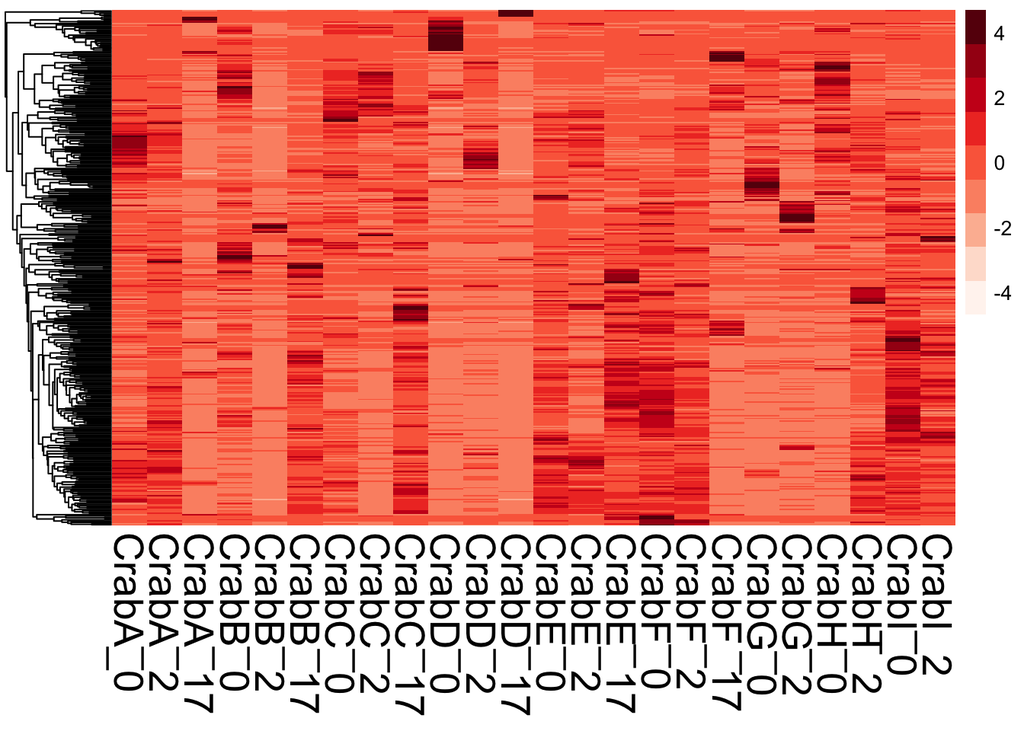

```r
pheatmap(noz_tempdegs.heatmap, scale = "row", cluster_row = TRUE, cluster_cols = FALSE, clustering_distance_rows = "euclidean", clustering_method = "average", show_rownames = FALSE, show_colnames = TRUE, treeheight_col = 80, legend = TRUE, color = heatmapReds, fontsize_col = 20, fontsize_row = 12)
```

Try with new color scheme so that value of 0 is white:

```r
heatmapRedBlue <- RColorBrewer::brewer.pal(11, "RdBu")
```

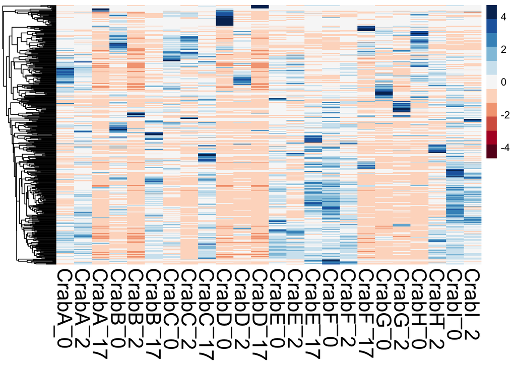

```r
pheatmap(noz_tempdegs.heatmap, scale = "row", cluster_row = TRUE, cluster_cols = FALSE, clustering_distance_rows = "euclidean", clustering_method = "average", show_rownames = FALSE, show_colnames = TRUE, treeheight_col = 80, legend = TRUE, color = heatmapRedBlue, fontsize_col = 20, fontsize_row = 12)
```

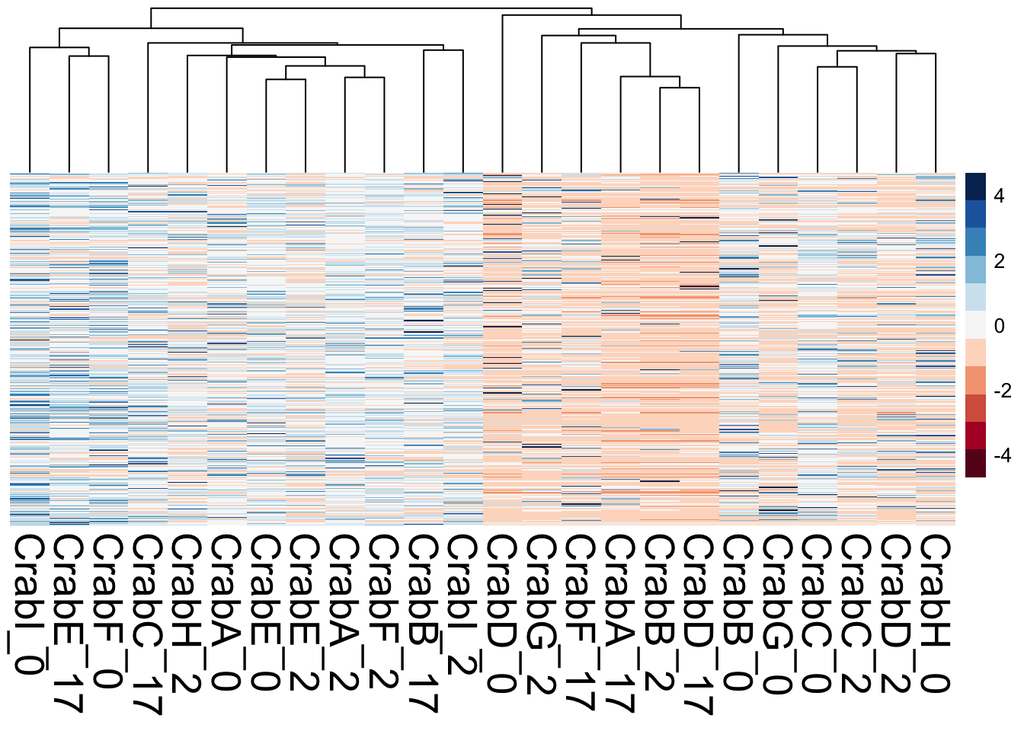

```r
pheatmap(noz_tempdegs.heatmap, scale = "row", cluster_row = FALSE, cluster_cols = TRUE, clustering_distance_rows = "euclidean", clustering_method = "average", show_rownames = FALSE, show_colnames = TRUE, treeheight_col = 80, legend = TRUE, color = heatmapRedBlue, fontsize_col = 20, fontsize_row = 12)
```

# INFECTION DEGs

## Create heatmap with infection DEG list

Just using crabs D (uninfected) and E (infected) across time

```r
infection_degs <- read.delim("../analyses/DEG-infection.txt", header = TRUE)
head(infection_degs)
```

```
##                 Trinity_ID baseMean log2FoldChange    lfcSE      stat   pvalue
## 1  TRINITY_DN1003_c0_g1_i4 26.88821      -8.099743 1.916726 -4.225822 2.38e-05
## 2 TRINITY_DN10053_c0_g1_i1 40.44398      -8.688937 1.791349 -4.850500 1.23e-06
## 3 TRINITY_DN10053_c0_g2_i1 70.89865      -5.867614 1.169758 -5.016094 5.27e-07
## 4 TRINITY_DN10062_c0_g1_i1 24.47404      -7.964749 1.994945 -3.992466 6.54e-05
## 5 TRINITY_DN10074_c0_g1_i1 33.58529      -8.421180 1.868968 -4.505793 6.61e-06
## 6 TRINITY_DN10074_c0_g2_i1 43.46756      -8.793361 1.810596 -4.856612 1.19e-06
##          padj
## 1 0.000871817
## 2 0.000060700
## 3 0.000028800
## 4 0.002205639
## 5 0.000276673
## 6 0.000059100
```

`join` with norm_counts by “Trinity_ID”

```r
infection_degs_counts <- left_join(norm_counts, infection_degs, by = "Trinity_ID")
head(infection_degs_counts)
```

```
##                 Trinity_ID CrabH_2 CrabE_2 CrabI_2 CrabC_17 CrabB_17 CrabG_0
## 1  TRINITY_DN5772_c0_g1_i1   0.000   0.000   0.000    0.000    0.000   0.000
## 2  TRINITY_DN2201_c0_g1_i1   0.406   0.000   1.537    0.000    0.000   0.000
## 3  TRINITY_DN4656_c0_g1_i1   2.445   7.675   1.673    3.277    2.057  28.523
## 4  TRINITY_DN7591_c0_g1_i1   3.369   1.049   1.366    0.444    6.289   0.000
## 5  TRINITY_DN6285_c0_g1_i4   0.000   0.000   0.000    1.806    0.000   0.000
## 6 TRINITY_DN28918_c0_g1_i1   0.000   0.000   0.000    0.000    1.520   0.000
##   CrabF_2 CrabE_0 CrabG_2 CrabC_0 CrabI_0 CrabD_0 CrabD_17 CrabB_0 CrabC_2
## 1   0.000   0.000       0    0.00   0.000       0        0   0.000   0.000
## 2   0.817   0.000       0    0.00   0.000       0        0   0.000   0.000
## 3   2.074   4.561       0    2.39   2.925       0        0   2.047   1.627
## 4   4.666   2.383       0    0.00  10.800       0        0   1.650   0.000
## 5   0.000   0.000       0    0.00   0.000       0        0   0.000   0.000
## 6   0.000   0.000       0    0.00   0.919       0        0   0.000   0.000
##   CrabB_2 CrabF_17 CrabA_0 CrabH_0 CrabA_17 CrabD_2 CrabE_17 CrabA_2 CrabF_0
## 1       0        0   0.000   0.000        0       0    0.000   1.976   0.000
## 2       0        0   0.000   0.000        0       0    7.232   0.000   2.599
## 3       0        0   6.384   2.853        0       0    2.853   4.987   2.019
## 4       0        0   0.839   0.000        0       0    8.787   5.773   8.427
## 5       0        0   0.000   0.000        0       0    1.397   0.000   0.000
## 6       0        0   1.990   0.000        0       0    0.000   0.000   0.000
##   baseMean log2FoldChange lfcSE stat pvalue padj
## 1       NA             NA    NA   NA     NA   NA
## 2       NA             NA    NA   NA     NA   NA
## 3       NA             NA    NA   NA     NA   NA
## 4       NA             NA    NA   NA     NA   NA
## 5       NA             NA    NA   NA     NA   NA
## 6       NA             NA    NA   NA     NA   NA
```

Just want the ones that match! (list of 772)

```r
infectdegs_counts_match <- filter(infection_degs_counts, baseMean != "NA")
head(infectdegs_counts_match)
```

```
##                 Trinity_ID CrabH_2 CrabE_2 CrabI_2 CrabC_17 CrabB_17 CrabG_0
## 1 TRINITY_DN13534_c0_g1_i1       0       0       0    0.000        0       0
## 2  TRINITY_DN5315_c0_g1_i1       0       0       0   16.633        0       0
## 3  TRINITY_DN9677_c0_g1_i1       0       0       0    0.000        0       0
## 4  TRINITY_DN4409_c0_g1_i1       0       0       0    0.000        0       0
## 5  TRINITY_DN7412_c0_g2_i1       0       0       0    0.000        0       0
## 6 TRINITY_DN22660_c0_g1_i1       0       0       0   18.183        0       0
##   CrabF_2 CrabE_0 CrabG_2 CrabC_0 CrabI_0 CrabD_0 CrabD_17 CrabB_0 CrabC_2
## 1       0       0       0       0       0       0        0   0.000       0
## 2       0       0       0       0       0       0        0   0.000       0
## 3       0       0       0       0       0       0        0   0.000       0
## 4       0       0       0       0       0       0        0   0.000       0
## 5       0       0       0       0       0       0        0   6.584       0
## 6       0       0       0       0       0       0        0   0.000       0
##   CrabB_2 CrabF_17 CrabA_0 CrabH_0 CrabA_17 CrabD_2 CrabE_17 CrabA_2 CrabF_0
## 1       0        0       0       0        0       0        0   0.000       0
## 2       0        0       0       0        0       0        0   0.000       0
## 3       0        0       0       0        0       0        0   0.000       0
## 4       0        0       0       0        0       0        0   0.000       0
## 5       0        0       0       0        0       0        0   1.936       0
## 6       0        0       0       0        0       0        0   0.000       0
##     baseMean log2FoldChange     lfcSE      stat       pvalue        padj
## 1  177.22414      -5.672793 1.0883505 -5.212285 1.870000e-07 0.000011200
## 2   42.40949      -6.403837 1.4338412 -4.466211 7.960000e-06 0.000326182
## 3  172.40468      -5.939028 1.0361297 -5.731934 9.930000e-09 0.000000911
## 4   31.94596      -4.464884 1.4289086 -3.124681 1.779980e-03 0.045755959
## 5 2823.53466       1.309240 0.3931856  3.329826 8.690030e-04 0.023934090
## 6   36.76023      -4.452340 1.4053150 -3.168215 1.533783e-03 0.040269470
```

Pull out just the sample count data:

```r
infectiondegs <- select(infectdegs_counts_match, Trinity_ID, CrabD_0, CrabD_2, CrabD_17, CrabE_0, CrabE_2, CrabE_17)
head(infectiondegs)
```

```
##                 Trinity_ID CrabD_0 CrabD_2 CrabD_17 CrabE_0 CrabE_2 CrabE_17
## 1 TRINITY_DN13534_c0_g1_i1       0       0        0       0       0        0
## 2  TRINITY_DN5315_c0_g1_i1       0       0        0       0       0        0
## 3  TRINITY_DN9677_c0_g1_i1       0       0        0       0       0        0
## 4  TRINITY_DN4409_c0_g1_i1       0       0        0       0       0        0
## 5  TRINITY_DN7412_c0_g2_i1       0       0        0       0       0        0
## 6 TRINITY_DN22660_c0_g1_i1       0       0        0       0       0        0
```

Set Trinity_ID as row names:

```r
rownames(infectiondegs) <- infectiondegs$Trinity_ID #set Trinity IDs as rownames
infectiondegs.heatmap <- infectiondegs[,-1] #remove redundant column
head(infectiondegs.heatmap)
```

```
##                          CrabD_0 CrabD_2 CrabD_17 CrabE_0 CrabE_2 CrabE_17
## TRINITY_DN13534_c0_g1_i1       0       0        0       0       0        0
## TRINITY_DN5315_c0_g1_i1        0       0        0       0       0        0
## TRINITY_DN9677_c0_g1_i1        0       0        0       0       0        0
## TRINITY_DN4409_c0_g1_i1        0       0        0       0       0        0
## TRINITY_DN7412_c0_g2_i1        0       0        0       0       0        0
## TRINITY_DN22660_c0_g1_i1       0       0        0       0       0        0
```

I think I should try to remove rows that have 0 all the way across:

```r
noz_infectiondegs.heatmap <- infectiondegs.heatmap[rowSums(infectiondegs.heatmap[, -1] >0) !=0, ]
head(noz_infectiondegs.heatmap)
```

```
##                         CrabD_0 CrabD_2 CrabD_17 CrabE_0 CrabE_2 CrabE_17
## TRINITY_DN2467_c0_g1_i6 145.889       0        0   1.742   1.686    0.000
## TRINITY_DN401_c0_g1_i8    0.000       0        0   1.468   1.873    3.668
## TRINITY_DN543_c0_g1_i3    0.000       0        0   1.753   1.272    3.136
## TRINITY_DN330_c1_g1_i2    6.124       0        0   0.000   0.000    4.704
## TRINITY_DN1070_c0_g1_i3   0.000       0        0   0.000   0.000    2.835
## TRINITY_DN3082_c0_g1_i4   0.000       0        0   0.096   0.000    0.000
```

now 144 rows!

Woo! it worked.

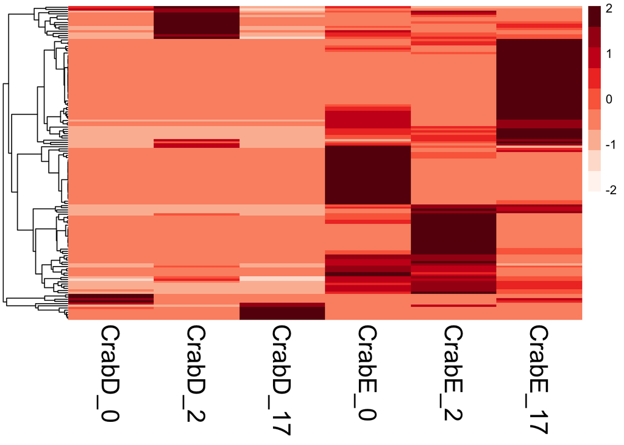

```r
pheatmap(noz_infectiondegs.heatmap, scale = "row", cluster_row = TRUE, cluster_cols = FALSE, clustering_distance_rows = "euclidean", clustering_method = "average", show_rownames = FALSE, show_colnames = TRUE, treeheight_col = 80, legend = TRUE, color = heatmapReds, fontsize_col = 20, fontsize_row = 12)
```

Try with heatmap Red-blue (0 value = white)

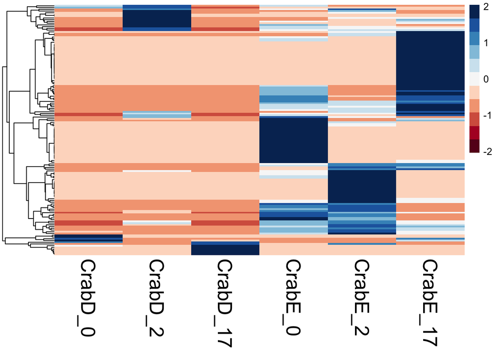

```r
pheatmap(noz_infectiondegs.heatmap, scale = "row", cluster_row = TRUE, cluster_cols = FALSE, clustering_distance_rows = "euclidean", clustering_method = "average", show_rownames = FALSE, show_colnames = TRUE, treeheight_col = 80, legend = TRUE, color = heatmapRedBlue, fontsize_col = 20, fontsize_row = 12)
```

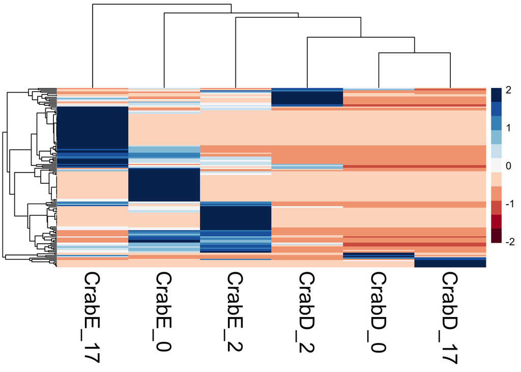

```r
pheatmap(noz_infectiondegs.heatmap, scale = "row", cluster_row = TRUE, cluster_cols = TRUE, clustering_distance_rows = "euclidean", clustering_method = "average", show_rownames = FALSE, show_colnames = TRUE, treeheight_col = 80, legend = TRUE, color = heatmapRedBlue, fontsize_col = 20, fontsize_row = 12)
```

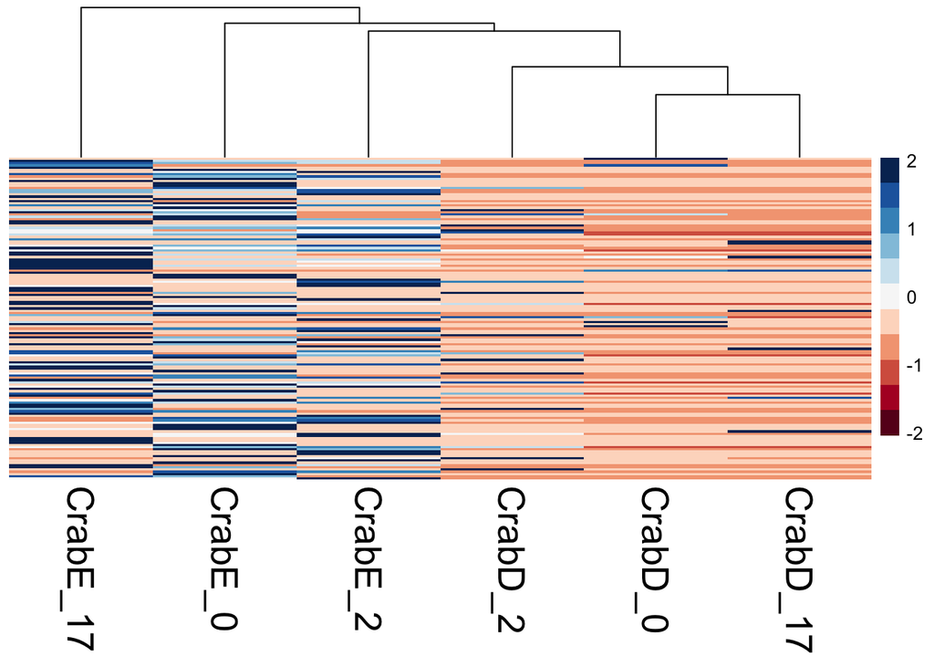

```r
pheatmap(noz_infectiondegs.heatmap, scale = "row", cluster_row = FALSE, cluster_cols = TRUE, clustering_distance_rows = "euclidean", clustering_method = "average", show_rownames = FALSE, show_colnames = TRUE, treeheight_col = 80, legend = TRUE, color = heatmapRedBlue, fontsize_col = 20, fontsize_row = 12)
```

Crab E - infected Crab D - uninfected

### same thing but with more crabs comparing infection over time (will show effects of temperature on infection)

Pull out just the sample count data:

```r
infectiondegs_allcrabs <- select(infectdegs_counts_match, Trinity_ID, CrabA_0, CrabA_2, CrabA_17, CrabB_0, CrabB_2, CrabB_17, CrabC_0, CrabC_2, CrabC_17, CrabD_0, CrabD_2, CrabD_17, CrabE_0, CrabE_2, CrabE_17, CrabF_0, CrabF_2, CrabF_17, CrabG_0, CrabG_2, CrabH_0, CrabH_2, CrabI_0, CrabI_2)
head(infectiondegs_allcrabs)
```

```
##                 Trinity_ID CrabA_0 CrabA_2 CrabA_17 CrabB_0 CrabB_2 CrabB_17
## 1 TRINITY_DN13534_c0_g1_i1       0   0.000        0   0.000       0        0
## 2  TRINITY_DN5315_c0_g1_i1       0   0.000        0   0.000       0        0
## 3  TRINITY_DN9677_c0_g1_i1       0   0.000        0   0.000       0        0
## 4  TRINITY_DN4409_c0_g1_i1       0   0.000        0   0.000       0        0
## 5  TRINITY_DN7412_c0_g2_i1       0   1.936        0   6.584       0        0
## 6 TRINITY_DN22660_c0_g1_i1       0   0.000        0   0.000       0        0
##   CrabC_0 CrabC_2 CrabC_17 CrabD_0 CrabD_2 CrabD_17 CrabE_0 CrabE_2 CrabE_17
## 1       0       0    0.000       0       0        0       0       0        0
## 2       0       0   16.633       0       0        0       0       0        0
## 3       0       0    0.000       0       0        0       0       0        0
## 4       0       0    0.000       0       0        0       0       0        0
## 5       0       0    0.000       0       0        0       0       0        0
## 6       0       0   18.183       0       0        0       0       0        0
##   CrabF_0 CrabF_2 CrabF_17 CrabG_0 CrabG_2 CrabH_0 CrabH_2 CrabI_0 CrabI_2
## 1       0       0        0       0       0       0       0       0       0
## 2       0       0        0       0       0       0       0       0       0
## 3       0       0        0       0       0       0       0       0       0
## 4       0       0        0       0       0       0       0       0       0
## 5       0       0        0       0       0       0       0       0       0
## 6       0       0        0       0       0       0       0       0       0
```

Set Trinity_ID as row names:

```r
rownames(infectiondegs_allcrabs) <- infectiondegs_allcrabs$Trinity_ID #set Trinity IDs as rownames
infectiondegs_allcrabs.heatmap <- infectiondegs_allcrabs[,-1] #remove redundant column
head(infectiondegs_allcrabs.heatmap)
```

```
##                          CrabA_0 CrabA_2 CrabA_17 CrabB_0 CrabB_2 CrabB_17
## TRINITY_DN13534_c0_g1_i1       0   0.000        0   0.000       0        0
## TRINITY_DN5315_c0_g1_i1        0   0.000        0   0.000       0        0
## TRINITY_DN9677_c0_g1_i1        0   0.000        0   0.000       0        0
## TRINITY_DN4409_c0_g1_i1        0   0.000        0   0.000       0        0
## TRINITY_DN7412_c0_g2_i1        0   1.936        0   6.584       0        0
## TRINITY_DN22660_c0_g1_i1       0   0.000        0   0.000       0        0
##                          CrabC_0 CrabC_2 CrabC_17 CrabD_0 CrabD_2 CrabD_17
## TRINITY_DN13534_c0_g1_i1       0       0    0.000       0       0        0
## TRINITY_DN5315_c0_g1_i1        0       0   16.633       0       0        0
## TRINITY_DN9677_c0_g1_i1        0       0    0.000       0       0        0
## TRINITY_DN4409_c0_g1_i1        0       0    0.000       0       0        0
## TRINITY_DN7412_c0_g2_i1        0       0    0.000       0       0        0
## TRINITY_DN22660_c0_g1_i1       0       0   18.183       0       0        0
##                          CrabE_0 CrabE_2 CrabE_17 CrabF_0 CrabF_2 CrabF_17
## TRINITY_DN13534_c0_g1_i1       0       0        0       0       0        0
## TRINITY_DN5315_c0_g1_i1        0       0        0       0       0        0
## TRINITY_DN9677_c0_g1_i1        0       0        0       0       0        0
## TRINITY_DN4409_c0_g1_i1        0       0        0       0       0        0
## TRINITY_DN7412_c0_g2_i1        0       0        0       0       0        0
## TRINITY_DN22660_c0_g1_i1       0       0        0       0       0        0
##                          CrabG_0 CrabG_2 CrabH_0 CrabH_2 CrabI_0 CrabI_2
## TRINITY_DN13534_c0_g1_i1       0       0       0       0       0       0
## TRINITY_DN5315_c0_g1_i1        0       0       0       0       0       0
## TRINITY_DN9677_c0_g1_i1        0       0       0       0       0       0
## TRINITY_DN4409_c0_g1_i1        0       0       0       0       0       0
## TRINITY_DN7412_c0_g2_i1        0       0       0       0       0       0
## TRINITY_DN22660_c0_g1_i1       0       0       0       0       0       0
```

I think I should try to remove rows that have 0 all the way across:

```r
noz_infectiondegs_allcrabs.heatmap <- infectiondegs_allcrabs.heatmap[rowSums(infectiondegs_allcrabs.heatmap[, -1] >0) !=0, ]
head(noz_infectiondegs_allcrabs.heatmap)
```

```
##                          CrabA_0 CrabA_2 CrabA_17 CrabB_0 CrabB_2 CrabB_17
## TRINITY_DN5315_c0_g1_i1        0   0.000        0   0.000       0    0.000
## TRINITY_DN7412_c0_g2_i1        0   1.936        0   6.584       0    0.000
## TRINITY_DN22660_c0_g1_i1       0   0.000        0   0.000       0    0.000
## TRINITY_DN13274_c0_g1_i1       0   0.000        0   0.000       0    0.000
## TRINITY_DN21813_c0_g1_i1       0   0.000        0   3.569       0    0.000
## TRINITY_DN26722_c0_g1_i1       0   0.000        0   5.733       0    3.215
##                          CrabC_0 CrabC_2 CrabC_17 CrabD_0 CrabD_2 CrabD_17
## TRINITY_DN5315_c0_g1_i1    0.000       0   16.633       0       0        0
## TRINITY_DN7412_c0_g2_i1    0.000       0    0.000       0       0        0
## TRINITY_DN22660_c0_g1_i1   0.000       0   18.183       0       0        0
## TRINITY_DN13274_c0_g1_i1   0.000       0    2.229       0       0        0
## TRINITY_DN21813_c0_g1_i1   4.976       0   17.947       0       0        0
## TRINITY_DN26722_c0_g1_i1   0.000       0    0.000       0       0        0
##                          CrabE_0 CrabE_2 CrabE_17 CrabF_0 CrabF_2 CrabF_17
## TRINITY_DN5315_c0_g1_i1        0       0        0       0       0        0
## TRINITY_DN7412_c0_g2_i1        0       0        0       0       0        0
## TRINITY_DN22660_c0_g1_i1       0       0        0       0       0        0
## TRINITY_DN13274_c0_g1_i1       0       0        0       0       0        0
## TRINITY_DN21813_c0_g1_i1       0       0        0       0       0        0
## TRINITY_DN26722_c0_g1_i1       0       0        0       0       0        0
##                          CrabG_0 CrabG_2 CrabH_0 CrabH_2 CrabI_0 CrabI_2
## TRINITY_DN5315_c0_g1_i1        0       0       0       0       0       0
## TRINITY_DN7412_c0_g2_i1        0       0       0       0       0       0
## TRINITY_DN22660_c0_g1_i1       0       0       0       0       0       0
## TRINITY_DN13274_c0_g1_i1       0       0       0       0       0       0
## TRINITY_DN21813_c0_g1_i1       0       0       0       0       0       0
## TRINITY_DN26722_c0_g1_i1       0       0       0       0       0       0
```

447 rows:

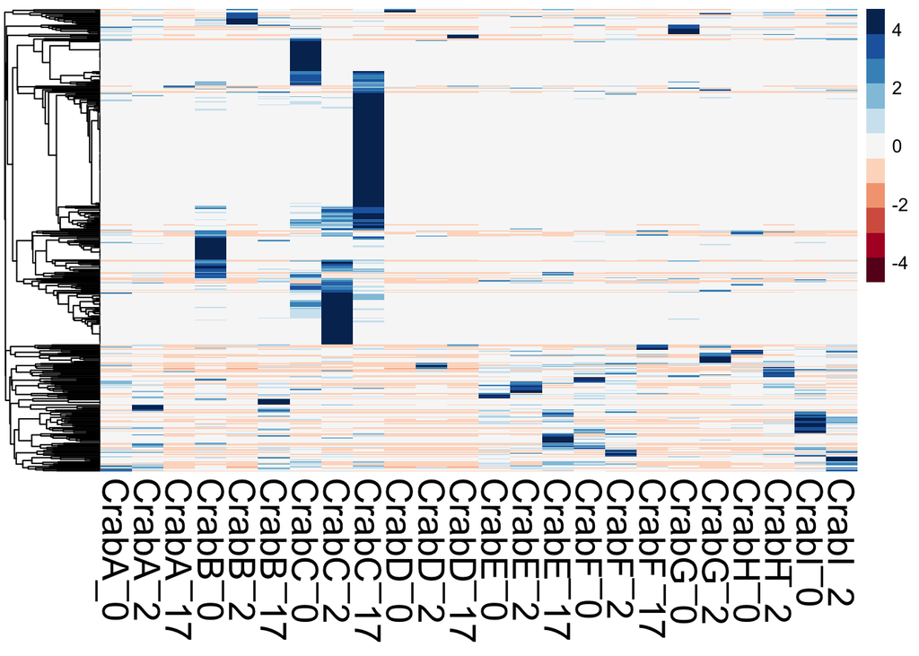

```r
pheatmap(noz_infectiondegs_allcrabs.heatmap, scale = "row", cluster_row = TRUE, cluster_cols = FALSE, clustering_distance_rows = "euclidean", clustering_method = "average", show_rownames = FALSE, show_colnames = TRUE, treeheight_col = 80, legend = TRUE, color = heatmapRedBlue, fontsize_col = 20, fontsize_row = 12)
```

### Try again with fewer samples

Pull out just the sample count data:

```r
infectiondegs_alltwodays <- select(infectdegs_counts_match, Trinity_ID, CrabA_0, CrabA_2, CrabB_0, CrabB_2, CrabC_0, CrabC_2, CrabD_0, CrabD_2, CrabE_0, CrabE_2, CrabF_0, CrabF_2, CrabG_0, CrabG_2, CrabH_0, CrabH_2, CrabI_0, CrabI_2)
head(infectiondegs_alltwodays)
```

```
##                 Trinity_ID CrabA_0 CrabA_2 CrabB_0 CrabB_2 CrabC_0 CrabC_2
## 1 TRINITY_DN13534_c0_g1_i1       0   0.000   0.000       0       0       0
## 2  TRINITY_DN5315_c0_g1_i1       0   0.000   0.000       0       0       0
## 3  TRINITY_DN9677_c0_g1_i1       0   0.000   0.000       0       0       0
## 4  TRINITY_DN4409_c0_g1_i1       0   0.000   0.000       0       0       0
## 5  TRINITY_DN7412_c0_g2_i1       0   1.936   6.584       0       0       0
## 6 TRINITY_DN22660_c0_g1_i1       0   0.000   0.000       0       0       0
##   CrabD_0 CrabD_2 CrabE_0 CrabE_2 CrabF_0 CrabF_2 CrabG_0 CrabG_2 CrabH_0
## 1       0       0       0       0       0       0       0       0       0
## 2       0       0       0       0       0       0       0       0       0
## 3       0       0       0       0       0       0       0       0       0
## 4       0       0       0       0       0       0       0       0       0
## 5       0       0       0       0       0       0       0       0       0
## 6       0       0       0       0       0       0       0       0       0
##   CrabH_2 CrabI_0 CrabI_2
## 1       0       0       0
## 2       0       0       0
## 3       0       0       0
## 4       0       0       0
## 5       0       0       0
## 6       0       0       0
```

Set Trinity_ID as row names:

```r
rownames(infectiondegs_alltwodays) <- infectiondegs_alltwodays$Trinity_ID #set Trinity IDs as rownames
infectiondegs_alltwodays.heatmap <-infectiondegs_alltwodays[,-1] #remove redundant column
head(infectiondegs_alltwodays.heatmap)
```

```
##                          CrabA_0 CrabA_2 CrabB_0 CrabB_2 CrabC_0 CrabC_2
## TRINITY_DN13534_c0_g1_i1       0   0.000   0.000       0       0       0
## TRINITY_DN5315_c0_g1_i1        0   0.000   0.000       0       0       0
## TRINITY_DN9677_c0_g1_i1        0   0.000   0.000       0       0       0
## TRINITY_DN4409_c0_g1_i1        0   0.000   0.000       0       0       0
## TRINITY_DN7412_c0_g2_i1        0   1.936   6.584       0       0       0
## TRINITY_DN22660_c0_g1_i1       0   0.000   0.000       0       0       0
##                          CrabD_0 CrabD_2 CrabE_0 CrabE_2 CrabF_0 CrabF_2
## TRINITY_DN13534_c0_g1_i1       0       0       0       0       0       0
## TRINITY_DN5315_c0_g1_i1        0       0       0       0       0       0
## TRINITY_DN9677_c0_g1_i1        0       0       0       0       0       0
## TRINITY_DN4409_c0_g1_i1        0       0       0       0       0       0
## TRINITY_DN7412_c0_g2_i1        0       0       0       0       0       0
## TRINITY_DN22660_c0_g1_i1       0       0       0       0       0       0
##                          CrabG_0 CrabG_2 CrabH_0 CrabH_2 CrabI_0 CrabI_2
## TRINITY_DN13534_c0_g1_i1       0       0       0       0       0       0
## TRINITY_DN5315_c0_g1_i1        0       0       0       0       0       0
## TRINITY_DN9677_c0_g1_i1        0       0       0       0       0       0
## TRINITY_DN4409_c0_g1_i1        0       0       0       0       0       0
## TRINITY_DN7412_c0_g2_i1        0       0       0       0       0       0
## TRINITY_DN22660_c0_g1_i1       0       0       0       0       0       0
```

I think I should try to remove rows that have 0 all the way across:

```r
noz_infectiondegs_alltwodays.heatmap <- infectiondegs_alltwodays.heatmap[rowSums(infectiondegs_alltwodays.heatmap[, -1] >0) !=0, ]
head(noz_infectiondegs_alltwodays.heatmap)
```

```
##                          CrabA_0 CrabA_2 CrabB_0 CrabB_2 CrabC_0 CrabC_2
## TRINITY_DN7412_c0_g2_i1        0   1.936   6.584       0   0.000   0.000
## TRINITY_DN21813_c0_g1_i1       0   0.000   3.569       0   4.976   0.000
## TRINITY_DN26722_c0_g1_i1       0   0.000   5.733       0   0.000   0.000
## TRINITY_DN3663_c0_g1_i7        0   0.000   0.000       0   0.000   0.000
## TRINITY_DN2331_c0_g1_i2        0   0.000   6.437       0   0.000   0.000
## TRINITY_DN26838_c0_g1_i1       0   0.000   0.000       0   0.000   4.599
##                          CrabD_0 CrabD_2 CrabE_0 CrabE_2 CrabF_0 CrabF_2
## TRINITY_DN7412_c0_g2_i1        0       0       0       0       0       0
## TRINITY_DN21813_c0_g1_i1       0       0       0       0       0       0
## TRINITY_DN26722_c0_g1_i1       0       0       0       0       0       0
## TRINITY_DN3663_c0_g1_i7        0       0       0       0       0       0
## TRINITY_DN2331_c0_g1_i2        0       0       0       0       0       0
## TRINITY_DN26838_c0_g1_i1       0       0       0       0       0       0
##                          CrabG_0 CrabG_2 CrabH_0 CrabH_2 CrabI_0 CrabI_2
## TRINITY_DN7412_c0_g2_i1        0       0   0.000       0   0.000   0.000
## TRINITY_DN21813_c0_g1_i1       0       0   0.000       0   0.000   0.000
## TRINITY_DN26722_c0_g1_i1       0       0   0.000       0   0.000   0.000
## TRINITY_DN3663_c0_g1_i7        0       0   0.000       0   0.415   0.000
## TRINITY_DN2331_c0_g1_i2        0       0   5.299       0  24.281   6.267
## TRINITY_DN26838_c0_g1_i1       0       0   0.000       0   0.000   0.000
```

349 rows

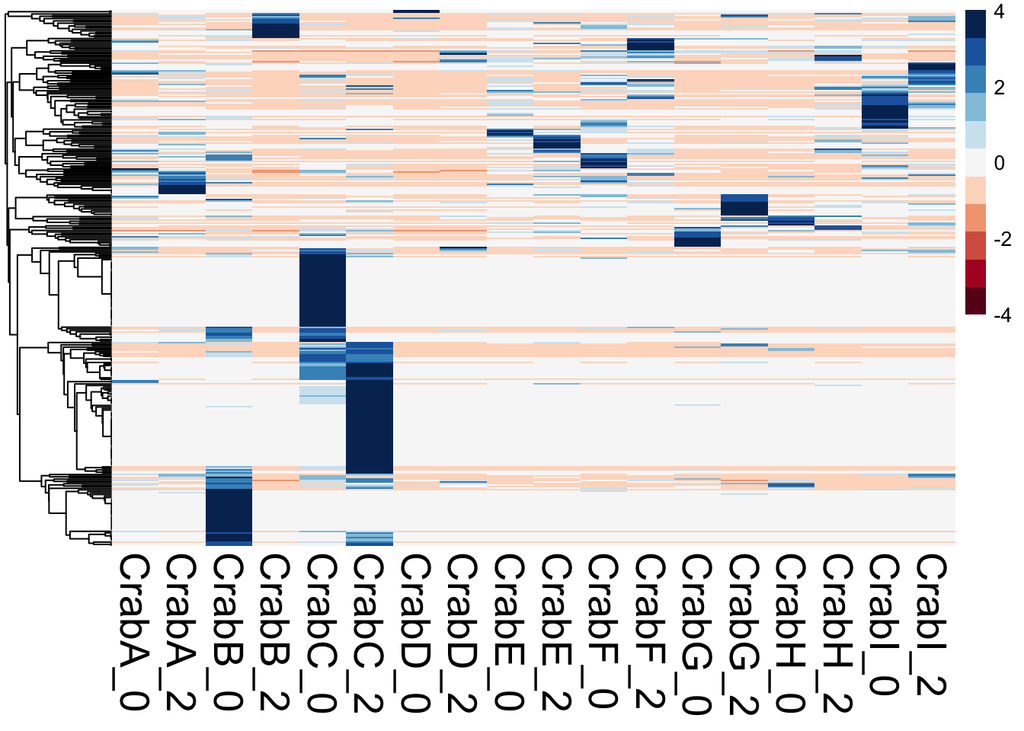

```r
pheatmap(noz_infectiondegs_alltwodays.heatmap, scale = "row", cluster_row = TRUE, cluster_cols = FALSE, clustering_distance_rows = "euclidean", clustering_method = "average", show_rownames = FALSE, show_colnames = TRUE, treeheight_col = 80, legend = TRUE, color = heatmapRedBlue, fontsize_col = 20, fontsize_row = 12)
```

### Now just ABC and GHI and E (infected cold) at two time points:

Pull out just the sample count data:

```r
infectiondegs_abceghitwodays <- select(infectdegs_counts_match, Trinity_ID, CrabA_0, CrabA_2, CrabB_0, CrabB_2, CrabC_0, CrabC_2, CrabE_0, CrabE_2, CrabG_0, CrabG_2, CrabH_0, CrabH_2, CrabI_0, CrabI_2)
head(infectiondegs_abceghitwodays)
```

```
##                 Trinity_ID CrabA_0 CrabA_2 CrabB_0 CrabB_2 CrabC_0 CrabC_2
## 1 TRINITY_DN13534_c0_g1_i1       0   0.000   0.000       0       0       0
## 2  TRINITY_DN5315_c0_g1_i1       0   0.000   0.000       0       0       0
## 3  TRINITY_DN9677_c0_g1_i1       0   0.000   0.000       0       0       0
## 4  TRINITY_DN4409_c0_g1_i1       0   0.000   0.000       0       0       0
## 5  TRINITY_DN7412_c0_g2_i1       0   1.936   6.584       0       0       0
## 6 TRINITY_DN22660_c0_g1_i1       0   0.000   0.000       0       0       0
##   CrabE_0 CrabE_2 CrabG_0 CrabG_2 CrabH_0 CrabH_2 CrabI_0 CrabI_2
## 1       0       0       0       0       0       0       0       0
## 2       0       0       0       0       0       0       0       0
## 3       0       0       0       0       0       0       0       0
## 4       0       0       0       0       0       0       0       0
## 5       0       0       0       0       0       0       0       0
## 6       0       0       0       0       0       0       0       0
```

Set Trinity_ID as row names:

```r
rownames(infectiondegs_abceghitwodays) <- infectiondegs_abceghitwodays$Trinity_ID #set Trinity IDs as rownames
infectiondegs_abceghitwodays.heatmap <-infectiondegs_abceghitwodays[,-1] #remove redundant column
head(infectiondegs_abceghitwodays.heatmap)
```

```
##                          CrabA_0 CrabA_2 CrabB_0 CrabB_2 CrabC_0 CrabC_2
## TRINITY_DN13534_c0_g1_i1       0   0.000   0.000       0       0       0
## TRINITY_DN5315_c0_g1_i1        0   0.000   0.000       0       0       0
## TRINITY_DN9677_c0_g1_i1        0   0.000   0.000       0       0       0
## TRINITY_DN4409_c0_g1_i1        0   0.000   0.000       0       0       0
## TRINITY_DN7412_c0_g2_i1        0   1.936   6.584       0       0       0
## TRINITY_DN22660_c0_g1_i1       0   0.000   0.000       0       0       0
##                          CrabE_0 CrabE_2 CrabG_0 CrabG_2 CrabH_0 CrabH_2
## TRINITY_DN13534_c0_g1_i1       0       0       0       0       0       0
## TRINITY_DN5315_c0_g1_i1        0       0       0       0       0       0
## TRINITY_DN9677_c0_g1_i1        0       0       0       0       0       0
## TRINITY_DN4409_c0_g1_i1        0       0       0       0       0       0
## TRINITY_DN7412_c0_g2_i1        0       0       0       0       0       0
## TRINITY_DN22660_c0_g1_i1       0       0       0       0       0       0
##                          CrabI_0 CrabI_2
## TRINITY_DN13534_c0_g1_i1       0       0
## TRINITY_DN5315_c0_g1_i1        0       0
## TRINITY_DN9677_c0_g1_i1        0       0
## TRINITY_DN4409_c0_g1_i1        0       0
## TRINITY_DN7412_c0_g2_i1        0       0
## TRINITY_DN22660_c0_g1_i1       0       0
```

I think I should try to remove rows that have 0 all the way across:

```r
noz_infectiondegs_abceghitwodays.heatmap <- infectiondegs_abceghitwodays.heatmap[rowSums(infectiondegs_abceghitwodays.heatmap[, -1] >0) !=0, ]
head(noz_infectiondegs_abceghitwodays.heatmap)
```

```
##                          CrabA_0 CrabA_2 CrabB_0 CrabB_2 CrabC_0 CrabC_2
## TRINITY_DN7412_c0_g2_i1        0   1.936   6.584       0   0.000   0.000
## TRINITY_DN21813_c0_g1_i1       0   0.000   3.569       0   4.976   0.000
## TRINITY_DN26722_c0_g1_i1       0   0.000   5.733       0   0.000   0.000
## TRINITY_DN3663_c0_g1_i7        0   0.000   0.000       0   0.000   0.000
## TRINITY_DN2331_c0_g1_i2        0   0.000   6.437       0   0.000   0.000
## TRINITY_DN26838_c0_g1_i1       0   0.000   0.000       0   0.000   4.599
##                          CrabE_0 CrabE_2 CrabG_0 CrabG_2 CrabH_0 CrabH_2
## TRINITY_DN7412_c0_g2_i1        0       0       0       0   0.000       0
## TRINITY_DN21813_c0_g1_i1       0       0       0       0   0.000       0
## TRINITY_DN26722_c0_g1_i1       0       0       0       0   0.000       0
## TRINITY_DN3663_c0_g1_i7        0       0       0       0   0.000       0
## TRINITY_DN2331_c0_g1_i2        0       0       0       0   5.299       0
## TRINITY_DN26838_c0_g1_i1       0       0       0       0   0.000       0
##                          CrabI_0 CrabI_2
## TRINITY_DN7412_c0_g2_i1    0.000   0.000
## TRINITY_DN21813_c0_g1_i1   0.000   0.000
## TRINITY_DN26722_c0_g1_i1   0.000   0.000
## TRINITY_DN3663_c0_g1_i7    0.415   0.000
## TRINITY_DN2331_c0_g1_i2   24.281   6.267
## TRINITY_DN26838_c0_g1_i1   0.000   0.000
```

345 rows

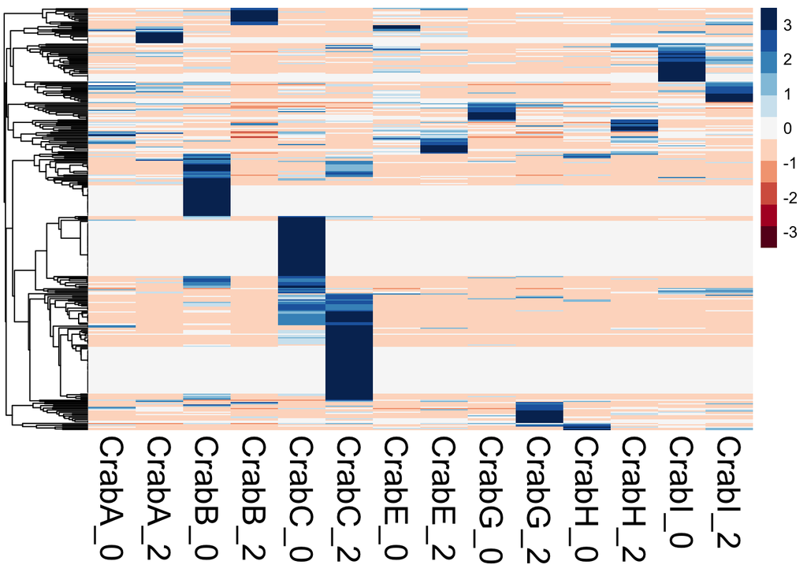

```r
pheatmap(noz_infectiondegs_abceghitwodays.heatmap, scale = "row", cluster_row = TRUE, cluster_cols = FALSE, clustering_distance_rows = "euclidean", clustering_method = "average", show_rownames = FALSE, show_colnames = TRUE, treeheight_col = 80, legend = TRUE, color = heatmapRedBlue, fontsize_col = 20, fontsize_row = 12)
```

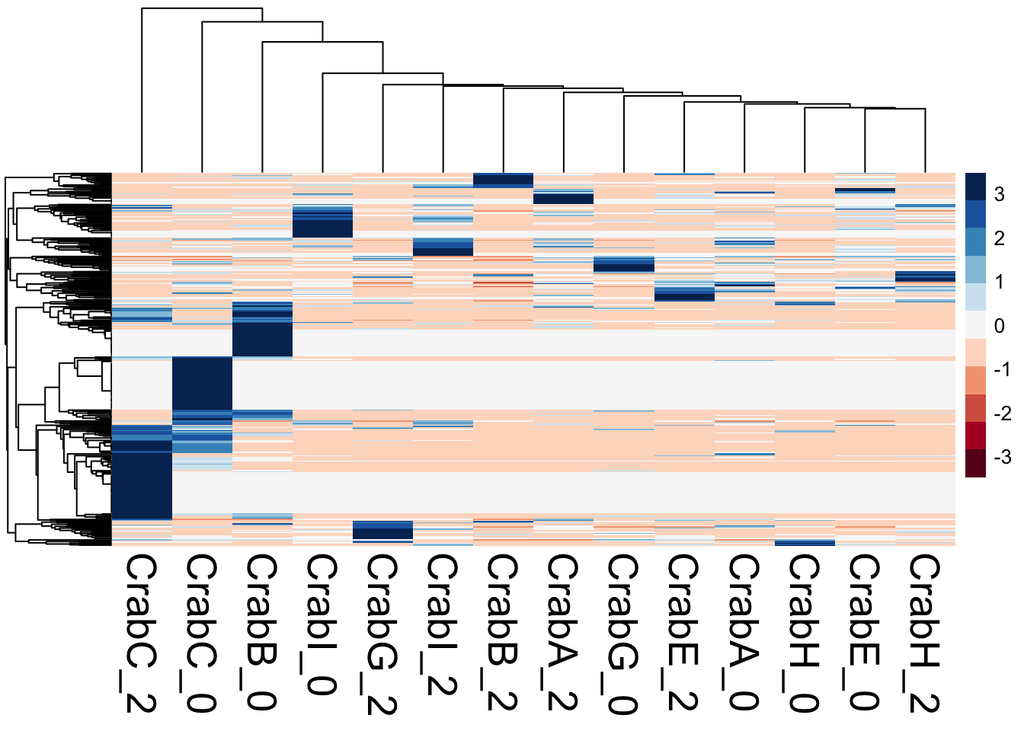

```r
pheatmap(noz_infectiondegs_abceghitwodays.heatmap, scale = "row", cluster_row = TRUE, cluster_cols = TRUE, clustering_distance_rows = "euclidean", clustering_method = "average", show_rownames = FALSE, show_colnames = TRUE, treeheight_col = 80, legend = TRUE, color = heatmapRedBlue, fontsize_col = 20, fontsize_row = 12)
```

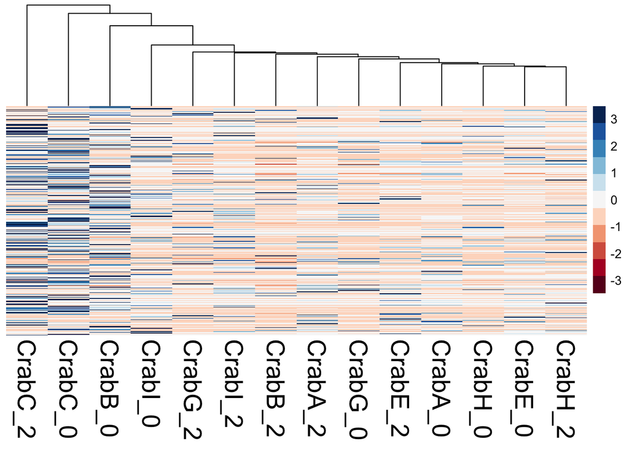

```r
pheatmap(noz_infectiondegs_abceghitwodays.heatmap, scale = "row", cluster_row = FALSE, cluster_cols = TRUE, clustering_distance_rows = "euclidean", clustering_method = "average", show_rownames = FALSE, show_colnames = TRUE, treeheight_col = 80, legend = TRUE, color = heatmapRedBlue, fontsize_col = 20, fontsize_row = 12)
```

Try same thing but with all day 0 on left, day 2 on right: Pull out just the sample count data:

```r
infectiondegs_abceghi_twodays <- select(infectdegs_counts_match, Trinity_ID, CrabA_0, CrabB_0, CrabC_0, CrabE_0, CrabG_0, CrabH_0, CrabI_0, CrabA_2, CrabB_2, CrabC_2, CrabE_2, CrabG_2, CrabH_2, CrabI_2)
head(infectiondegs_abceghi_twodays)
```

```
##                 Trinity_ID CrabA_0 CrabB_0 CrabC_0 CrabE_0 CrabG_0 CrabH_0
## 1 TRINITY_DN13534_c0_g1_i1       0   0.000       0       0       0       0
## 2  TRINITY_DN5315_c0_g1_i1       0   0.000       0       0       0       0
## 3  TRINITY_DN9677_c0_g1_i1       0   0.000       0       0       0       0
## 4  TRINITY_DN4409_c0_g1_i1       0   0.000       0       0       0       0
## 5  TRINITY_DN7412_c0_g2_i1       0   6.584       0       0       0       0
## 6 TRINITY_DN22660_c0_g1_i1       0   0.000       0       0       0       0
##   CrabI_0 CrabA_2 CrabB_2 CrabC_2 CrabE_2 CrabG_2 CrabH_2 CrabI_2
## 1       0   0.000       0       0       0       0       0       0
## 2       0   0.000       0       0       0       0       0       0
## 3       0   0.000       0       0       0       0       0       0
## 4       0   0.000       0       0       0       0       0       0
## 5       0   1.936       0       0       0       0       0       0
## 6       0   0.000       0       0       0       0       0       0
```

Set Trinity_ID as row names:

```r
rownames(infectiondegs_abceghi_twodays) <- infectiondegs_abceghi_twodays$Trinity_ID #set Trinity IDs as rownames
infectiondegs_abceghi_twodays.heatmap <-infectiondegs_abceghi_twodays[,-1] #remove redundant column
head(infectiondegs_abceghi_twodays.heatmap)
```

```
##                          CrabA_0 CrabB_0 CrabC_0 CrabE_0 CrabG_0 CrabH_0
## TRINITY_DN13534_c0_g1_i1       0   0.000       0       0       0       0
## TRINITY_DN5315_c0_g1_i1        0   0.000       0       0       0       0
## TRINITY_DN9677_c0_g1_i1        0   0.000       0       0       0       0
## TRINITY_DN4409_c0_g1_i1        0   0.000       0       0       0       0
## TRINITY_DN7412_c0_g2_i1        0   6.584       0       0       0       0
## TRINITY_DN22660_c0_g1_i1       0   0.000       0       0       0       0
##                          CrabI_0 CrabA_2 CrabB_2 CrabC_2 CrabE_2 CrabG_2
## TRINITY_DN13534_c0_g1_i1       0   0.000       0       0       0       0
## TRINITY_DN5315_c0_g1_i1        0   0.000       0       0       0       0
## TRINITY_DN9677_c0_g1_i1        0   0.000       0       0       0       0
## TRINITY_DN4409_c0_g1_i1        0   0.000       0       0       0       0
## TRINITY_DN7412_c0_g2_i1        0   1.936       0       0       0       0
## TRINITY_DN22660_c0_g1_i1       0   0.000       0       0       0       0
##                          CrabH_2 CrabI_2
## TRINITY_DN13534_c0_g1_i1       0       0
## TRINITY_DN5315_c0_g1_i1        0       0
## TRINITY_DN9677_c0_g1_i1        0       0
## TRINITY_DN4409_c0_g1_i1        0       0
## TRINITY_DN7412_c0_g2_i1        0       0
## TRINITY_DN22660_c0_g1_i1       0       0
```

I think I should try to remove rows that have 0 all the way across:

```r
noz_infectiondegs_abceghi_twodays.heatmap <- infectiondegs_abceghi_twodays.heatmap[rowSums(infectiondegs_abceghi_twodays.heatmap[, -1] >0) !=0, ]
head(noz_infectiondegs_abceghi_twodays.heatmap)
```

```
##                          CrabA_0 CrabB_0 CrabC_0 CrabE_0 CrabG_0 CrabH_0
## TRINITY_DN7412_c0_g2_i1        0   6.584   0.000       0       0   0.000
## TRINITY_DN21813_c0_g1_i1       0   3.569   4.976       0       0   0.000
## TRINITY_DN26722_c0_g1_i1       0   5.733   0.000       0       0   0.000
## TRINITY_DN3663_c0_g1_i7        0   0.000   0.000       0       0   0.000
## TRINITY_DN2331_c0_g1_i2        0   6.437   0.000       0       0   5.299
## TRINITY_DN26838_c0_g1_i1       0   0.000   0.000       0       0   0.000
##                          CrabI_0 CrabA_2 CrabB_2 CrabC_2 CrabE_2 CrabG_2
## TRINITY_DN7412_c0_g2_i1    0.000   1.936       0   0.000       0       0
## TRINITY_DN21813_c0_g1_i1   0.000   0.000       0   0.000       0       0
## TRINITY_DN26722_c0_g1_i1   0.000   0.000       0   0.000       0       0
## TRINITY_DN3663_c0_g1_i7    0.415   0.000       0   0.000       0       0
## TRINITY_DN2331_c0_g1_i2   24.281   0.000       0   0.000       0       0
## TRINITY_DN26838_c0_g1_i1   0.000   0.000       0   4.599       0       0
##                          CrabH_2 CrabI_2
## TRINITY_DN7412_c0_g2_i1        0   0.000
## TRINITY_DN21813_c0_g1_i1       0   0.000
## TRINITY_DN26722_c0_g1_i1       0   0.000
## TRINITY_DN3663_c0_g1_i7        0   0.000
## TRINITY_DN2331_c0_g1_i2        0   6.267
## TRINITY_DN26838_c0_g1_i1       0   0.000
```

345 rows

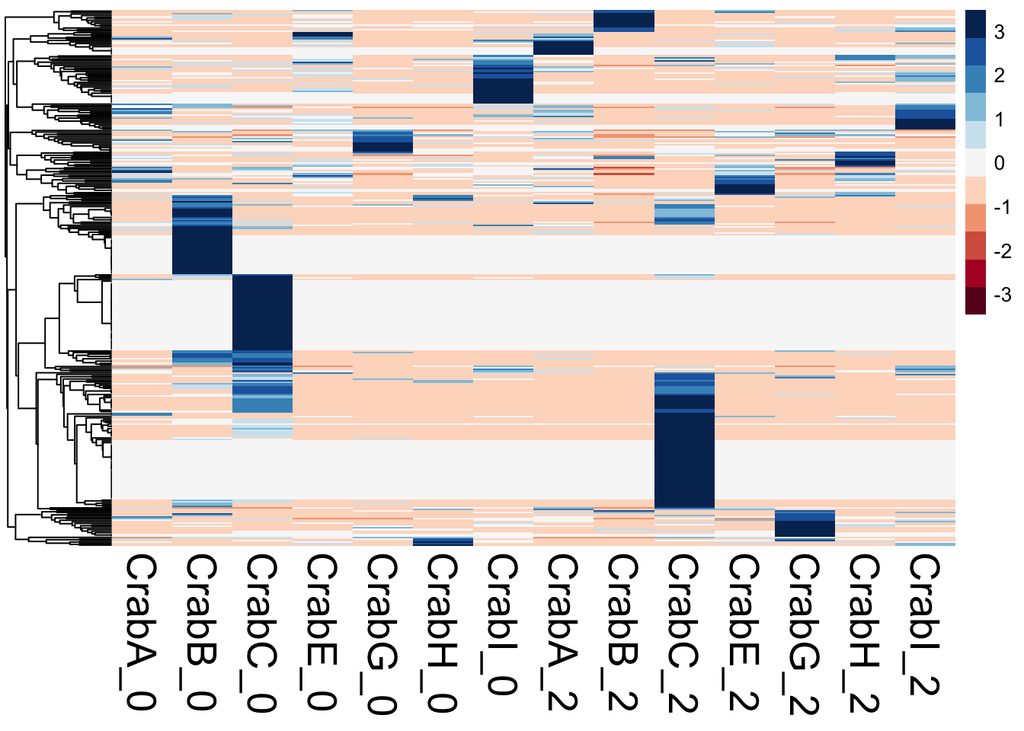

```r
pheatmap(noz_infectiondegs_abceghi_twodays.heatmap, scale = "row", cluster_row = TRUE, cluster_cols = FALSE, clustering_distance_rows = "euclidean", clustering_method = "average", show_rownames = FALSE, show_colnames = TRUE, treeheight_col = 80, legend = TRUE, color = heatmapRedBlue, fontsize_col = 20, fontsize_row = 12)
```

## Now with just Day 2 all samples and infection DEGs

Pull out just the sample count data:

```r
infectiondegs_alldaytwo <- select(infectdegs_counts_match, Trinity_ID, CrabA_2, CrabB_2, CrabC_2, CrabD_2, CrabE_2, CrabF_2, CrabG_2, CrabH_2, CrabI_2)
head(infectiondegs_alldaytwo)
```

```
##                 Trinity_ID CrabA_2 CrabB_2 CrabC_2 CrabD_2 CrabE_2 CrabF_2
## 1 TRINITY_DN13534_c0_g1_i1   0.000       0       0       0       0       0
## 2  TRINITY_DN5315_c0_g1_i1   0.000       0       0       0       0       0
## 3  TRINITY_DN9677_c0_g1_i1   0.000       0       0       0       0       0
## 4  TRINITY_DN4409_c0_g1_i1   0.000       0       0       0       0       0
## 5  TRINITY_DN7412_c0_g2_i1   1.936       0       0       0       0       0
## 6 TRINITY_DN22660_c0_g1_i1   0.000       0       0       0       0       0
##   CrabG_2 CrabH_2 CrabI_2
## 1       0       0       0
## 2       0       0       0
## 3       0       0       0
## 4       0       0       0
## 5       0       0       0
## 6       0       0       0
```

Set Trinity_ID as row names:

```r
rownames(infectiondegs_alldaytwo) <- infectiondegs_alldaytwo$Trinity_ID #set Trinity IDs as rownames
infectiondegs_alldaytwo.heatmap <-infectiondegs_alldaytwo[,-1] #remove redundant column
head(infectiondegs_alldaytwo.heatmap)
```

```
##                          CrabA_2 CrabB_2 CrabC_2 CrabD_2 CrabE_2 CrabF_2
## TRINITY_DN13534_c0_g1_i1   0.000       0       0       0       0       0
## TRINITY_DN5315_c0_g1_i1    0.000       0       0       0       0       0
## TRINITY_DN9677_c0_g1_i1    0.000       0       0       0       0       0
## TRINITY_DN4409_c0_g1_i1    0.000       0       0       0       0       0
## TRINITY_DN7412_c0_g2_i1    1.936       0       0       0       0       0
## TRINITY_DN22660_c0_g1_i1   0.000       0       0       0       0       0
##                          CrabG_2 CrabH_2 CrabI_2
## TRINITY_DN13534_c0_g1_i1       0       0       0
## TRINITY_DN5315_c0_g1_i1        0       0       0
## TRINITY_DN9677_c0_g1_i1        0       0       0
## TRINITY_DN4409_c0_g1_i1        0       0       0
## TRINITY_DN7412_c0_g2_i1        0       0       0
## TRINITY_DN22660_c0_g1_i1       0       0       0
```

I think I should try to remove rows that have 0 all the way across:

```r
noz_infectiondegs_alldaytwo.heatmap <- infectiondegs_alldaytwo.heatmap[rowSums(infectiondegs_alldaytwo.heatmap[, -1] >0) !=0, ]
head(noz_infectiondegs_alldaytwo.heatmap)
```

```
##                          CrabA_2 CrabB_2 CrabC_2 CrabD_2 CrabE_2 CrabF_2
## TRINITY_DN2331_c0_g1_i2        0    0.00   0.000       0   0.000   0.000
## TRINITY_DN26838_c0_g1_i1       0    0.00   4.599       0   0.000   0.000
## TRINITY_DN2467_c0_g1_i6        0    2.71   0.000       0   1.686   2.047
## TRINITY_DN8177_c0_g1_i1        0    0.00   2.486       0   0.000   0.000
## TRINITY_DN1442_c0_g1_i9        0    0.00   0.000       0   0.000   0.000
## TRINITY_DN1439_c0_g1_i1        0    0.00   0.000       0   0.000   0.000
##                          CrabG_2 CrabH_2 CrabI_2
## TRINITY_DN2331_c0_g1_i2    0.000    0.00   6.267
## TRINITY_DN26838_c0_g1_i1   0.000    0.00   0.000
## TRINITY_DN2467_c0_g1_i6    0.000    0.00   0.000
## TRINITY_DN8177_c0_g1_i1    0.000    0.00   0.000
## TRINITY_DN1442_c0_g1_i9   17.812   26.62   6.093
## TRINITY_DN1439_c0_g1_i1    0.000    0.00   3.252
```

252 rows

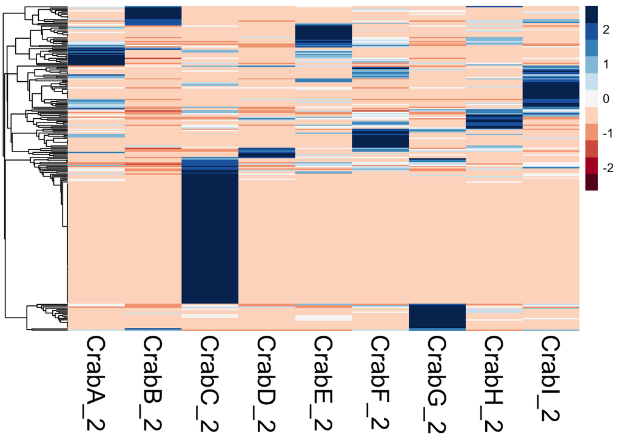

```r
pheatmap(noz_infectiondegs_alldaytwo.heatmap, scale = "row", cluster_row = TRUE, cluster_cols = FALSE, clustering_distance_rows = "euclidean", clustering_method = "average", show_rownames = FALSE, show_colnames = TRUE, treeheight_col = 80, legend = TRUE, color = heatmapRedBlue, fontsize_col = 20, fontsize_row = 12)
```

## Just infected crabs at day two (exclude D and F)

Pull out just the sample count data:

```r
infectiondegs_infectdaytwo <- select(infectdegs_counts_match, Trinity_ID, CrabA_2, CrabB_2, CrabC_2, CrabE_2, CrabG_2, CrabH_2, CrabI_2)
head(infectiondegs_infectdaytwo)
```

```
##                 Trinity_ID CrabA_2 CrabB_2 CrabC_2 CrabE_2 CrabG_2 CrabH_2
## 1 TRINITY_DN13534_c0_g1_i1   0.000       0       0       0       0       0
## 2  TRINITY_DN5315_c0_g1_i1   0.000       0       0       0       0       0
## 3  TRINITY_DN9677_c0_g1_i1   0.000       0       0       0       0       0
## 4  TRINITY_DN4409_c0_g1_i1   0.000       0       0       0       0       0
## 5  TRINITY_DN7412_c0_g2_i1   1.936       0       0       0       0       0
## 6 TRINITY_DN22660_c0_g1_i1   0.000       0       0       0       0       0
##   CrabI_2
## 1       0
## 2       0
## 3       0
## 4       0
## 5       0
## 6       0
```

Set Trinity_ID as row names:

```r
rownames(infectiondegs_infectdaytwo) <- infectiondegs_infectdaytwo$Trinity_ID #set Trinity IDs as rownames
infectiondegs_infectdaytwo.heatmap <-infectiondegs_infectdaytwo[,-1] #remove redundant column
head(infectiondegs_infectdaytwo.heatmap)
```

```
##                          CrabA_2 CrabB_2 CrabC_2 CrabE_2 CrabG_2 CrabH_2
## TRINITY_DN13534_c0_g1_i1   0.000       0       0       0       0       0
## TRINITY_DN5315_c0_g1_i1    0.000       0       0       0       0       0
## TRINITY_DN9677_c0_g1_i1    0.000       0       0       0       0       0
## TRINITY_DN4409_c0_g1_i1    0.000       0       0       0       0       0
## TRINITY_DN7412_c0_g2_i1    1.936       0       0       0       0       0
## TRINITY_DN22660_c0_g1_i1   0.000       0       0       0       0       0
##                          CrabI_2
## TRINITY_DN13534_c0_g1_i1       0
## TRINITY_DN5315_c0_g1_i1        0
## TRINITY_DN9677_c0_g1_i1        0
## TRINITY_DN4409_c0_g1_i1        0
## TRINITY_DN7412_c0_g2_i1        0
## TRINITY_DN22660_c0_g1_i1       0
```

I think I should try to remove rows that have 0 all the way across:

```r
noz_infectiondegs_infectdaytwo.heatmap <- infectiondegs_infectdaytwo.heatmap[rowSums(infectiondegs_infectdaytwo.heatmap[, -1] >0) !=0, ]
head(noz_infectiondegs_infectdaytwo.heatmap)
```

```
##                          CrabA_2 CrabB_2 CrabC_2 CrabE_2 CrabG_2 CrabH_2
## TRINITY_DN2331_c0_g1_i2        0    0.00   0.000   0.000   0.000    0.00
## TRINITY_DN26838_c0_g1_i1       0    0.00   4.599   0.000   0.000    0.00
## TRINITY_DN2467_c0_g1_i6        0    2.71   0.000   1.686   0.000    0.00
## TRINITY_DN8177_c0_g1_i1        0    0.00   2.486   0.000   0.000    0.00
## TRINITY_DN1442_c0_g1_i9        0    0.00   0.000   0.000  17.812   26.62
## TRINITY_DN1439_c0_g1_i1        0    0.00   0.000   0.000   0.000    0.00
##                          CrabI_2
## TRINITY_DN2331_c0_g1_i2    6.267
## TRINITY_DN26838_c0_g1_i1   0.000
## TRINITY_DN2467_c0_g1_i6    0.000
## TRINITY_DN8177_c0_g1_i1    0.000
## TRINITY_DN1442_c0_g1_i9    6.093
## TRINITY_DN1439_c0_g1_i1    3.252
```

242 rows

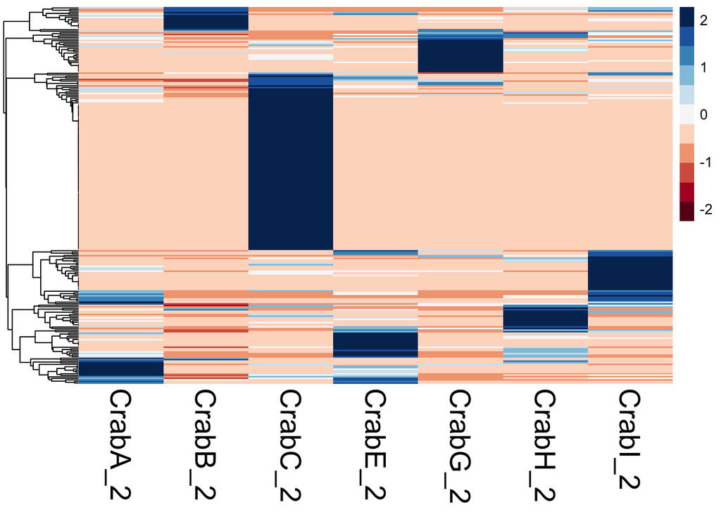

```r
pheatmap(noz_infectiondegs_infectdaytwo.heatmap, scale = "row", cluster_row = TRUE, cluster_cols = FALSE, clustering_distance_rows = "euclidean", clustering_method = "average", show_rownames = FALSE, show_colnames = TRUE, treeheight_col = 80, legend = TRUE, color = heatmapRedBlue, fontsize_col = 20, fontsize_row = 12)
```

Just infected crabs at day 2. ABC - ambient. E- decreased. GHI - elevated.

cluster by columns

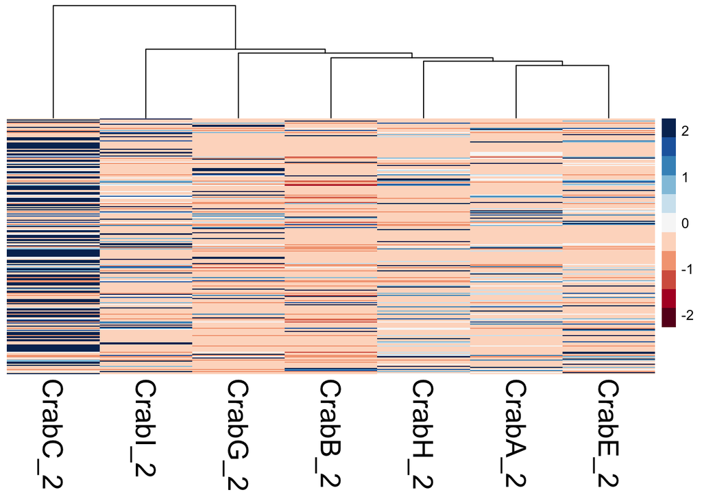

```r
pheatmap(noz_infectiondegs_infectdaytwo.heatmap, scale = "row", cluster_row = FALSE, cluster_cols = TRUE, clustering_distance_rows = "euclidean", clustering_method = "average", show_rownames = FALSE, show_colnames = TRUE, treeheight_col = 80, legend = TRUE, color = heatmapRedBlue, fontsize_col = 20, fontsize_row = 12)
```

Cluster by both:

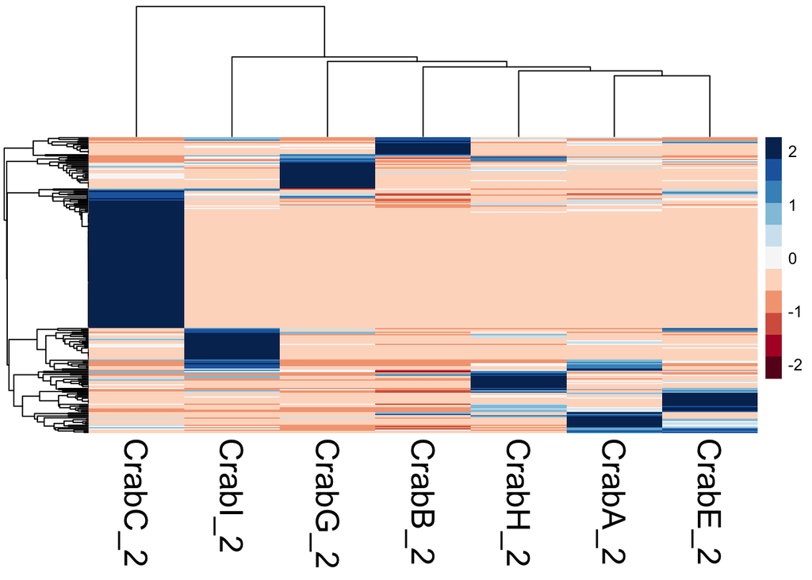

```r
pheatmap(noz_infectiondegs_infectdaytwo.heatmap, scale = "row", cluster_row = TRUE, cluster_cols = TRUE, clustering_distance_rows = "euclidean", clustering_method = "average", show_rownames = FALSE, show_colnames = TRUE, treeheight_col = 80, legend = TRUE, color = heatmapRedBlue, fontsize_col = 20, fontsize_row = 12)
```

## Crab A and E all time points with infection DEGs

Pull out just the sample count data:

```r
infectiondegs_AvE <- select(infectdegs_counts_match, Trinity_ID, CrabA_0, CrabA_2, CrabA_17, CrabE_0, CrabE_2, CrabE_17)
head(infectiondegs_AvE)
```

```
##                 Trinity_ID CrabA_0 CrabA_2 CrabA_17 CrabE_0 CrabE_2 CrabE_17
## 1 TRINITY_DN13534_c0_g1_i1       0   0.000        0       0       0        0
## 2  TRINITY_DN5315_c0_g1_i1       0   0.000        0       0       0        0
## 3  TRINITY_DN9677_c0_g1_i1       0   0.000        0       0       0        0
## 4  TRINITY_DN4409_c0_g1_i1       0   0.000        0       0       0        0
## 5  TRINITY_DN7412_c0_g2_i1       0   1.936        0       0       0        0
## 6 TRINITY_DN22660_c0_g1_i1       0   0.000        0       0       0        0
```

Set Trinity_ID as row names:

```r
rownames(infectiondegs_AvE) <- infectiondegs_AvE$Trinity_ID #set Trinity IDs as rownames
infectiondegs_AvE.heatmap <-infectiondegs_AvE[,-1] #remove redundant column
head(infectiondegs_AvE.heatmap)
```

```
##                          CrabA_0 CrabA_2 CrabA_17 CrabE_0 CrabE_2 CrabE_17
## TRINITY_DN13534_c0_g1_i1       0   0.000        0       0       0        0
## TRINITY_DN5315_c0_g1_i1        0   0.000        0       0       0        0
## TRINITY_DN9677_c0_g1_i1        0   0.000        0       0       0        0
## TRINITY_DN4409_c0_g1_i1        0   0.000        0       0       0        0
## TRINITY_DN7412_c0_g2_i1        0   1.936        0       0       0        0
## TRINITY_DN22660_c0_g1_i1       0   0.000        0       0       0        0
```

I think I should try to remove rows that have 0 all the way across:

```r
noz_infectiondegs_AvE.heatmap <- infectiondegs_AvE.heatmap[rowSums(infectiondegs_AvE.heatmap[, -1] >0) !=0, ]
head(noz_infectiondegs_AvE.heatmap)
```

```
##                         CrabA_0 CrabA_2 CrabA_17 CrabE_0 CrabE_2 CrabE_17
## TRINITY_DN7412_c0_g2_i1   0.000   1.936        0   0.000   0.000    0.000
## TRINITY_DN2467_c0_g1_i6   0.000   0.000        0   1.742   1.686    0.000
## TRINITY_DN401_c0_g1_i8    0.307   1.784        0   1.468   1.873    3.668
## TRINITY_DN4279_c0_g1_i1   0.000   1.617        0   0.000   0.000    0.000
## TRINITY_DN543_c0_g1_i3    0.000   6.586        0   1.753   1.272    3.136
## TRINITY_DN330_c1_g1_i2    0.000   2.673        0   0.000   0.000    4.704
```

150 rows

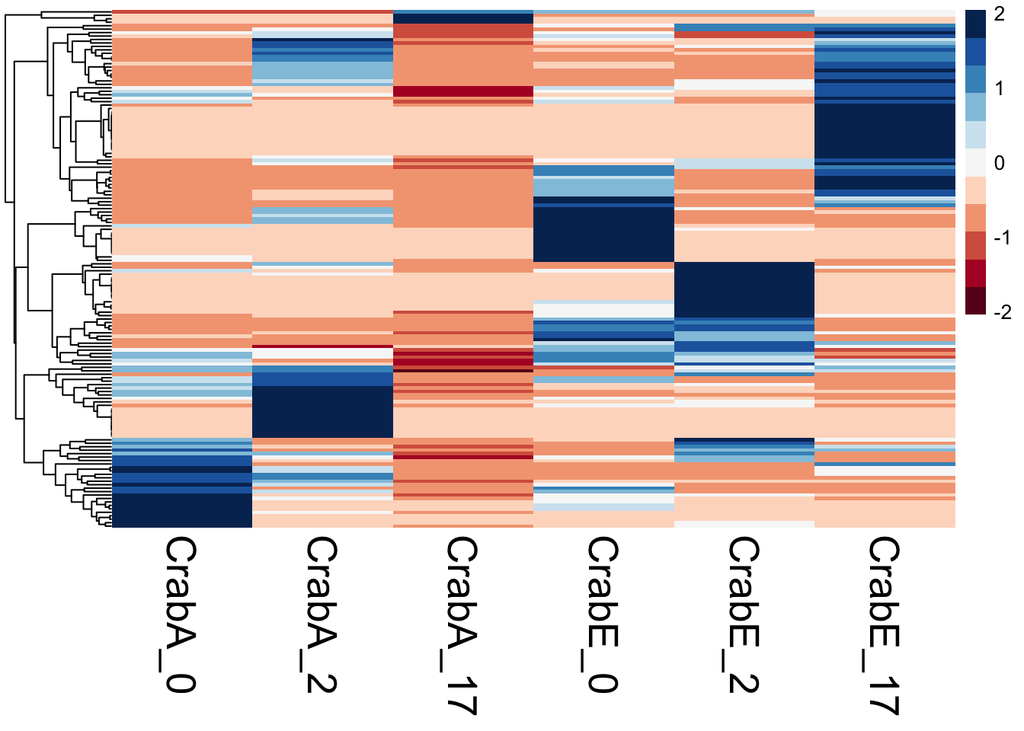

```r
pheatmap(noz_infectiondegs_AvE.heatmap, scale = "row", cluster_row = TRUE, cluster_cols = FALSE, clustering_distance_rows = "euclidean", clustering_method = "average", show_rownames = FALSE, show_colnames = TRUE, treeheight_col = 80, legend = TRUE, color = heatmapRedBlue, fontsize_col = 20, fontsize_row = 12)
```

Crab A - ambient infected Crab E - cold infected

## Crab B v E all time points with infection DEGs

Pull out just the sample count data:

```r
infectiondegs_BvE <- select(infectdegs_counts_match, Trinity_ID, CrabB_0, CrabB_2, CrabB_17, CrabE_0, CrabE_2, CrabE_17)
head(infectiondegs_BvE)
```

```
##                 Trinity_ID CrabB_0 CrabB_2 CrabB_17 CrabE_0 CrabE_2 CrabE_17
## 1 TRINITY_DN13534_c0_g1_i1   0.000       0        0       0       0        0
## 2  TRINITY_DN5315_c0_g1_i1   0.000       0        0       0       0        0
## 3  TRINITY_DN9677_c0_g1_i1   0.000       0        0       0       0        0
## 4  TRINITY_DN4409_c0_g1_i1   0.000       0        0       0       0        0
## 5  TRINITY_DN7412_c0_g2_i1   6.584       0        0       0       0        0
## 6 TRINITY_DN22660_c0_g1_i1   0.000       0        0       0       0        0
```

Set Trinity_ID as row names:

```r
rownames(infectiondegs_BvE) <- infectiondegs_BvE$Trinity_ID #set Trinity IDs as rownames
infectiondegs_BvE.heatmap <-infectiondegs_BvE[,-1] #remove redundant column
head(infectiondegs_BvE.heatmap)
```

```
##                          CrabB_0 CrabB_2 CrabB_17 CrabE_0 CrabE_2 CrabE_17
## TRINITY_DN13534_c0_g1_i1   0.000       0        0       0       0        0
## TRINITY_DN5315_c0_g1_i1    0.000       0        0       0       0        0
## TRINITY_DN9677_c0_g1_i1    0.000       0        0       0       0        0
## TRINITY_DN4409_c0_g1_i1    0.000       0        0       0       0        0
## TRINITY_DN7412_c0_g2_i1    6.584       0        0       0       0        0
## TRINITY_DN22660_c0_g1_i1   0.000       0        0       0       0        0
```

I think I should try to remove rows that have 0 all the way across:

```r
noz_infectiondegs_BvE.heatmap <- infectiondegs_BvE.heatmap[rowSums(infectiondegs_BvE.heatmap[, -1] >0) !=0, ]
head(noz_infectiondegs_BvE.heatmap)
```

```
##                          CrabB_0 CrabB_2 CrabB_17 CrabE_0 CrabE_2 CrabE_17
## TRINITY_DN26722_c0_g1_i1   5.733   0.000    3.215   0.000   0.000    0.000
## TRINITY_DN2467_c0_g1_i6    0.000   2.710    0.000   1.742   1.686    0.000
## TRINITY_DN401_c0_g1_i8     0.000   0.621    2.322   1.468   1.873    3.668
## TRINITY_DN4279_c0_g1_i1    0.000   0.000    0.444   0.000   0.000    0.000
## TRINITY_DN543_c0_g1_i3     0.000   0.000    5.116   1.753   1.272    3.136
## TRINITY_DN330_c1_g1_i2     0.664   6.742    0.497   0.000   0.000    4.704
```

170 rows

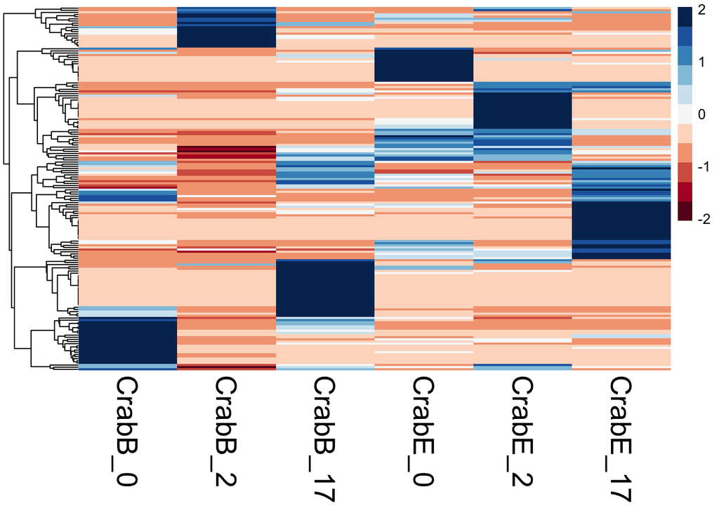

```r
pheatmap(noz_infectiondegs_BvE.heatmap, scale = "row", cluster_row = TRUE, cluster_cols = FALSE, clustering_distance_rows = "euclidean", clustering_method = "average", show_rownames = FALSE, show_colnames = TRUE, treeheight_col = 80, legend = TRUE, color = heatmapRedBlue, fontsize_col = 20, fontsize_row = 12)
```

Crab B ambient infected Crab E cold infected

## **Crab C and E all time points with infection DEGs**

*This one will be used for thesis defense* Pull out just the sample count data:

```r
infectiondegs_CvE <- select(infectdegs_counts_match, Trinity_ID, CrabC_0, CrabC_2, CrabC_17, CrabE_0, CrabE_2, CrabE_17)
head(infectiondegs_CvE)
```

```
##                 Trinity_ID CrabC_0 CrabC_2 CrabC_17 CrabE_0 CrabE_2 CrabE_17
## 1 TRINITY_DN13534_c0_g1_i1       0       0    0.000       0       0        0
## 2  TRINITY_DN5315_c0_g1_i1       0       0   16.633       0       0        0
## 3  TRINITY_DN9677_c0_g1_i1       0       0    0.000       0       0        0
## 4  TRINITY_DN4409_c0_g1_i1       0       0    0.000       0       0        0
## 5  TRINITY_DN7412_c0_g2_i1       0       0    0.000       0       0        0
## 6 TRINITY_DN22660_c0_g1_i1       0       0   18.183       0       0        0
```

Set Trinity_ID as row names:

```r
rownames(infectiondegs_CvE) <- infectiondegs_CvE$Trinity_ID #set Trinity IDs as rownames
infectiondegs_CvE.heatmap <-infectiondegs_CvE[,-1] #remove redundant column
head(infectiondegs_CvE.heatmap)
```

```
##                          CrabC_0 CrabC_2 CrabC_17 CrabE_0 CrabE_2 CrabE_17
## TRINITY_DN13534_c0_g1_i1       0       0    0.000       0       0        0
## TRINITY_DN5315_c0_g1_i1        0       0   16.633       0       0        0
## TRINITY_DN9677_c0_g1_i1        0       0    0.000       0       0        0
## TRINITY_DN4409_c0_g1_i1        0       0    0.000       0       0        0
## TRINITY_DN7412_c0_g2_i1        0       0    0.000       0       0        0
## TRINITY_DN22660_c0_g1_i1       0       0   18.183       0       0        0
```

I think I should try to remove rows that have 0 all the way across:

```r
noz_infectiondegs_CvE.heatmap <- infectiondegs_CvE.heatmap[rowSums(infectiondegs_CvE.heatmap[, -1] >0) !=0, ]
head(noz_infectiondegs_CvE.heatmap)
```

```
##                          CrabC_0 CrabC_2 CrabC_17 CrabE_0 CrabE_2 CrabE_17
## TRINITY_DN5315_c0_g1_i1    0.000   0.000   16.633   0.000   0.000        0
## TRINITY_DN22660_c0_g1_i1   0.000   0.000   18.183   0.000   0.000        0
## TRINITY_DN13274_c0_g1_i1   0.000   0.000    2.229   0.000   0.000        0
## TRINITY_DN21813_c0_g1_i1   4.976   0.000   17.947   0.000   0.000        0
## TRINITY_DN26838_c0_g1_i1   0.000   4.599    6.877   0.000   0.000        0
## TRINITY_DN2467_c0_g1_i6    0.000   0.000    0.000   1.742   1.686        0
```

366 rows!

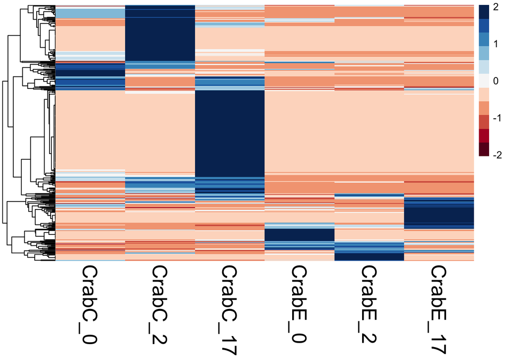

```r
pheatmap(noz_infectiondegs_CvE.heatmap, scale = "row", cluster_row = TRUE, cluster_cols = FALSE, clustering_distance_rows = "euclidean", clustering_method = "average", show_rownames = FALSE, show_colnames = TRUE, treeheight_col = 80, legend = TRUE, color = heatmapRedBlue, fontsize_col = 20, fontsize_row = 12)
```

### Try to get the genes that correspond to those blue clusters

from here: https://stackoverflow.com/questions/27820158/pheatmap-in-r-how-to-get-clusters

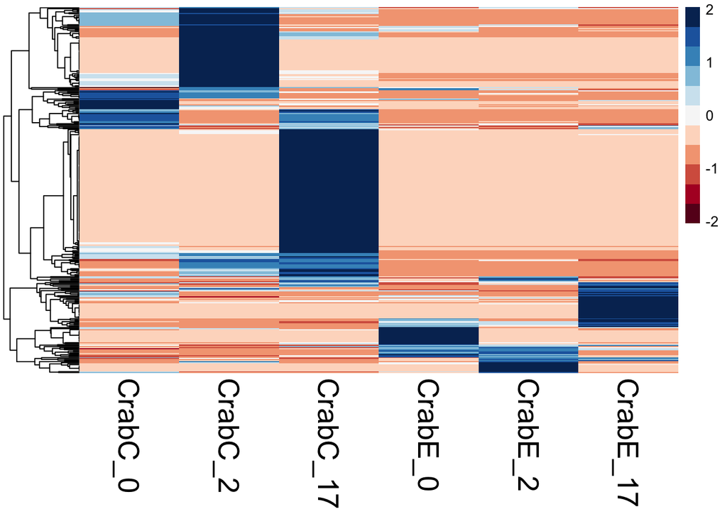

```r
#set the C v E heatmap as an object
results <-
pheatmap(noz_infectiondegs_CvE.heatmap, scale = "row", cluster_row = TRUE, cluster_cols = FALSE, clustering_distance_rows = "euclidean", clustering_method = "average", show_rownames = FALSE, show_colnames = TRUE, treeheight_col = 80, legend = TRUE, color = heatmapRedBlue, fontsize_col = 20, fontsize_row = 12)
```

extract 10 clusters.

```r
CvE.clust <- cbind(noz_infectiondegs_CvE.heatmap,
                   cluster = cutree(results$tree_row,
                                     k = 10))
head(CvE.clust)
```

```
##                          CrabC_0 CrabC_2 CrabC_17 CrabE_0 CrabE_2 CrabE_17
## TRINITY_DN5315_c0_g1_i1    0.000   0.000   16.633   0.000   0.000        0
## TRINITY_DN22660_c0_g1_i1   0.000   0.000   18.183   0.000   0.000        0
## TRINITY_DN13274_c0_g1_i1   0.000   0.000    2.229   0.000   0.000        0
## TRINITY_DN21813_c0_g1_i1   4.976   0.000   17.947   0.000   0.000        0
## TRINITY_DN26838_c0_g1_i1   0.000   4.599    6.877   0.000   0.000        0
## TRINITY_DN2467_c0_g1_i6    0.000   0.000    0.000   1.742   1.686        0
##                          cluster
## TRINITY_DN5315_c0_g1_i1        1
## TRINITY_DN22660_c0_g1_i1       1
## TRINITY_DN13274_c0_g1_i1       1
## TRINITY_DN21813_c0_g1_i1       1
## TRINITY_DN26838_c0_g1_i1       1
## TRINITY_DN2467_c0_g1_i6        2
```

Not super clear which cluster number applies to which visual cluster.

Next attempt: from here - https://www.biostars.org/p/287512/

Use the same “results” object (the heatmap) as I did above:

```r
#re-order the data used to create the heatmap in the same order as what is shown in the heatmap (top to bottom)
reorg_CvE_genes <- rownames(noz_infectiondegs_CvE.heatmap[results$tree_row[["order"]],])
head(reorg_CvE_genes)
```

```
## [1] "TRINITY_DN5910_c0_g1_i1"  "TRINITY_DN209_c0_g1_i1"
## [3] "TRINITY_DN26588_c0_g1_i1" "TRINITY_DN262_c0_g1_i1"
## [5] "TRINITY_DN10667_c0_g1_i1" "TRINITY_DN3196_c0_g1_i1"
```

366 characters. Good because C v E heatmap has 366 genes!

```r
#now 'cut' the data into a pre-selected number of groups.
#not really sure how to figure out number of groups... but there seems to be 6 big blue clusters in the Crab C and Crab E heatmap...
sixclust <- sort(cutree(results$tree_row, k=6))
head(sixclust)
```

```
##  TRINITY_DN5315_c0_g1_i1 TRINITY_DN22660_c0_g1_i1 TRINITY_DN13274_c0_g1_i1
##                        1                        1                        1
## TRINITY_DN21813_c0_g1_i1 TRINITY_DN26838_c0_g1_i1  TRINITY_DN4618_c0_g2_i1
##                        1                        1                        1
```

That isn’t super different from my original attempt.

Try plotting the cluster dendrogram

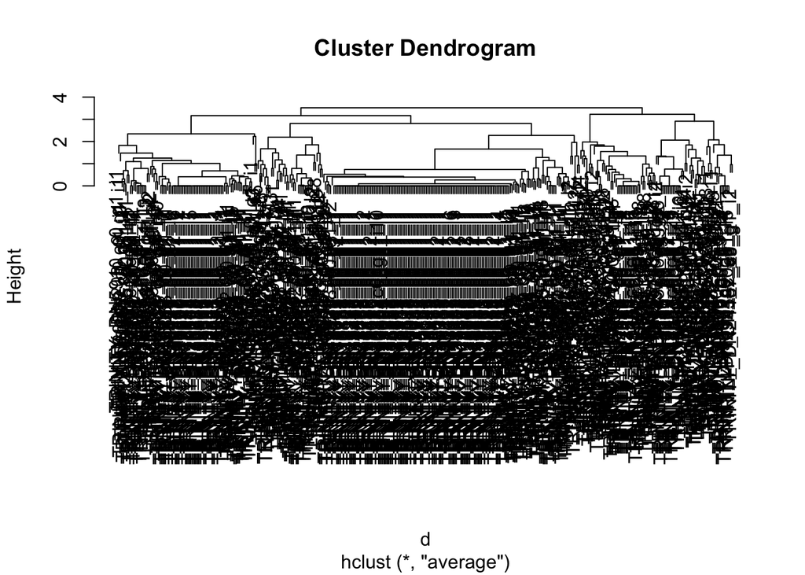

```r
plot(results$tree_row)
abline(h=7, col = "red", lty = 2, lwd =2)
```

not useful.

```r
euc_clust <- sort(cutree(results$tree_row, h =7))
head(euc_clust)
```

```
##  TRINITY_DN5315_c0_g1_i1 TRINITY_DN22660_c0_g1_i1 TRINITY_DN13274_c0_g1_i1
##                        1                        1                        1
## TRINITY_DN21813_c0_g1_i1 TRINITY_DN26838_c0_g1_i1  TRINITY_DN2467_c0_g1_i6
##                        1                        1                        1
```

I don’t think that is helpful at all. The tree is too messy.

# ABC v GHI at day 2 DEG list

## Create heatmap using ABC v GHI DEG list (5) on all samples:

Read in ABC v GHI DEG list (5)

```r
ABCGHI_degs <- read.delim("../analyses/DEG-ABCGHI.txt", header = TRUE)
head(ABCGHI_degs)
```

```
##                Trinity_ID baseMean log2FoldChange    lfcSE     stat   pvalue
## 1 TRINITY_DN1456_c0_g1_i1 19.93296       22.24248 3.685323 6.035420 1.59e-09
## 2 TRINITY_DN1994_c0_g2_i2 17.03947       22.02570 3.688969 5.970692 2.36e-09
## 3  TRINITY_DN365_c0_g1_i1 16.71797       21.99850 3.689601 5.962297 2.49e-09
## 4 TRINITY_DN3830_c0_g1_i1 17.68247       22.07914 3.687840 5.987013 2.14e-09
## 5 TRINITY_DN3962_c0_g1_i7 31.18544       22.86783 3.684685 6.206182 5.43e-10
##       padj
## 1 1.42e-05
## 2 1.42e-05
## 3 1.42e-05
## 4 1.42e-05
## 5 1.42e-05
```

`join` with norm_counts by “Trinity_ID”

```r
ABCGHI_degs_counts <- left_join(norm_counts, ABCGHI_degs, by = "Trinity_ID")
head(ABCGHI_degs_counts)
```

```
##                 Trinity_ID CrabH_2 CrabE_2 CrabI_2 CrabC_17 CrabB_17 CrabG_0
## 1  TRINITY_DN5772_c0_g1_i1   0.000   0.000   0.000    0.000    0.000   0.000
## 2  TRINITY_DN2201_c0_g1_i1   0.406   0.000   1.537    0.000    0.000   0.000
## 3  TRINITY_DN4656_c0_g1_i1   2.445   7.675   1.673    3.277    2.057  28.523
## 4  TRINITY_DN7591_c0_g1_i1   3.369   1.049   1.366    0.444    6.289   0.000
## 5  TRINITY_DN6285_c0_g1_i4   0.000   0.000   0.000    1.806    0.000   0.000
## 6 TRINITY_DN28918_c0_g1_i1   0.000   0.000   0.000    0.000    1.520   0.000
##   CrabF_2 CrabE_0 CrabG_2 CrabC_0 CrabI_0 CrabD_0 CrabD_17 CrabB_0 CrabC_2
## 1   0.000   0.000       0    0.00   0.000       0        0   0.000   0.000
## 2   0.817   0.000       0    0.00   0.000       0        0   0.000   0.000
## 3   2.074   4.561       0    2.39   2.925       0        0   2.047   1.627
## 4   4.666   2.383       0    0.00  10.800       0        0   1.650   0.000
## 5   0.000   0.000       0    0.00   0.000       0        0   0.000   0.000
## 6   0.000   0.000       0    0.00   0.919       0        0   0.000   0.000
##   CrabB_2 CrabF_17 CrabA_0 CrabH_0 CrabA_17 CrabD_2 CrabE_17 CrabA_2 CrabF_0
## 1       0        0   0.000   0.000        0       0    0.000   1.976   0.000
## 2       0        0   0.000   0.000        0       0    7.232   0.000   2.599
## 3       0        0   6.384   2.853        0       0    2.853   4.987   2.019
## 4       0        0   0.839   0.000        0       0    8.787   5.773   8.427
## 5       0        0   0.000   0.000        0       0    1.397   0.000   0.000
## 6       0        0   1.990   0.000        0       0    0.000   0.000   0.000
##   baseMean log2FoldChange lfcSE stat pvalue padj
## 1       NA             NA    NA   NA     NA   NA
## 2       NA             NA    NA   NA     NA   NA
## 3       NA             NA    NA   NA     NA   NA
## 4       NA             NA    NA   NA     NA   NA
## 5       NA             NA    NA   NA     NA   NA
## 6       NA             NA    NA   NA     NA   NA
```

Just want the ones that match! (list of 5)

```r
ABCGHI_degs_counts_match <- filter(ABCGHI_degs_counts, baseMean != "NA")
head(ABCGHI_degs_counts_match)
```

```
##                Trinity_ID CrabH_2 CrabE_2 CrabI_2 CrabC_17 CrabB_17 CrabG_0
## 1 TRINITY_DN1994_c0_g2_i2       0   0.000       0    0.000    0.000   8.712
## 2 TRINITY_DN3962_c0_g1_i7       0   0.000       0    0.000   20.532   0.000
## 3 TRINITY_DN1456_c0_g1_i1       0   0.000       0    0.000   39.814   0.000
## 4  TRINITY_DN365_c0_g1_i1       0   0.000       0    0.000    0.000   0.000
## 5 TRINITY_DN3830_c0_g1_i1       0   6.001       0   38.084   18.696   0.000
##   CrabF_2 CrabE_0 CrabG_2 CrabC_0 CrabI_0 CrabD_0 CrabD_17 CrabB_0 CrabC_2
## 1  14.454   0.000 197.278       0  18.624       0        0  40.323       0
## 2   2.286   0.000  62.175       0   0.000       0        0   0.000       0
## 3   0.000   0.000 226.162       0   0.000       0        0 838.191       0
## 4   0.000   0.834  42.887       0   0.000       0        0   0.000       0
## 5   0.000   3.599  39.247       0  12.763       0        0   0.000       0
##   CrabB_2 CrabF_17 CrabA_0 CrabH_0 CrabA_17 CrabD_2 CrabE_17 CrabA_2 CrabF_0
## 1       0        0   0.000  95.808        0       0    5.468       0   7.198
## 2       0        0   0.000   0.000        0       0    0.000       0   0.000
## 3       0        0   0.000   0.000        0       0   12.390       0   1.593
## 4       0        0   0.694   3.482        0       0    0.000       0   0.000
## 5       0        0   0.000   0.000        0       0   14.721       0   0.000
##   baseMean log2FoldChange    lfcSE     stat   pvalue     padj
## 1 17.03947       22.02570 3.688969 5.970692 2.36e-09 1.42e-05
## 2 31.18544       22.86783 3.684685 6.206182 5.43e-10 1.42e-05
## 3 19.93296       22.24248 3.685323 6.035420 1.59e-09 1.42e-05
## 4 16.71797       21.99850 3.689601 5.962297 2.49e-09 1.42e-05
## 5 17.68247       22.07914 3.687840 5.987013 2.14e-09 1.42e-05
```

Pull out sample columns:

```r
abcghidegs_allcrabs <- select(ABCGHI_degs_counts_match, Trinity_ID, CrabA_0, CrabA_2, CrabA_17, CrabB_0, CrabB_2, CrabB_17, CrabC_0, CrabC_2, CrabC_17, CrabD_0, CrabD_2, CrabD_17, CrabE_0, CrabE_2, CrabE_17, CrabF_0, CrabF_2, CrabF_17, CrabG_0, CrabG_2, CrabH_0, CrabH_2, CrabI_0, CrabI_2)
head(abcghidegs_allcrabs)
```

```
##                Trinity_ID CrabA_0 CrabA_2 CrabA_17 CrabB_0 CrabB_2 CrabB_17
## 1 TRINITY_DN1994_c0_g2_i2   0.000       0        0  40.323       0    0.000
## 2 TRINITY_DN3962_c0_g1_i7   0.000       0        0   0.000       0   20.532
## 3 TRINITY_DN1456_c0_g1_i1   0.000       0        0 838.191       0   39.814
## 4  TRINITY_DN365_c0_g1_i1   0.694       0        0   0.000       0    0.000
## 5 TRINITY_DN3830_c0_g1_i1   0.000       0        0   0.000       0   18.696
##   CrabC_0 CrabC_2 CrabC_17 CrabD_0 CrabD_2 CrabD_17 CrabE_0 CrabE_2 CrabE_17
## 1       0       0    0.000       0       0        0   0.000   0.000    5.468
## 2       0       0    0.000       0       0        0   0.000   0.000    0.000
## 3       0       0    0.000       0       0        0   0.000   0.000   12.390
## 4       0       0    0.000       0       0        0   0.834   0.000    0.000
## 5       0       0   38.084       0       0        0   3.599   6.001   14.721
##   CrabF_0 CrabF_2 CrabF_17 CrabG_0 CrabG_2 CrabH_0 CrabH_2 CrabI_0 CrabI_2
## 1   7.198  14.454        0   8.712 197.278  95.808       0  18.624       0
## 2   0.000   2.286        0   0.000  62.175   0.000       0   0.000       0
## 3   1.593   0.000        0   0.000 226.162   0.000       0   0.000       0
## 4   0.000   0.000        0   0.000  42.887   3.482       0   0.000       0
## 5   0.000   0.000        0   0.000  39.247   0.000       0  12.763       0
```

Set Trinity_ID as row names:

```r
rownames(abcghidegs_allcrabs) <- abcghidegs_allcrabs$Trinity_ID #set Trinity IDs as rownames
ABCGHIdegs_all.heatmap <- abcghidegs_allcrabs[,-1] #remove redundant column
head(ABCGHIdegs_all.heatmap)
```

```
##                         CrabA_0 CrabA_2 CrabA_17 CrabB_0 CrabB_2 CrabB_17
## TRINITY_DN1994_c0_g2_i2   0.000       0        0  40.323       0    0.000
## TRINITY_DN3962_c0_g1_i7   0.000       0        0   0.000       0   20.532
## TRINITY_DN1456_c0_g1_i1   0.000       0        0 838.191       0   39.814
## TRINITY_DN365_c0_g1_i1    0.694       0        0   0.000       0    0.000
## TRINITY_DN3830_c0_g1_i1   0.000       0        0   0.000       0   18.696
##                         CrabC_0 CrabC_2 CrabC_17 CrabD_0 CrabD_2 CrabD_17
## TRINITY_DN1994_c0_g2_i2       0       0    0.000       0       0        0
## TRINITY_DN3962_c0_g1_i7       0       0    0.000       0       0        0
## TRINITY_DN1456_c0_g1_i1       0       0    0.000       0       0        0
## TRINITY_DN365_c0_g1_i1        0       0    0.000       0       0        0
## TRINITY_DN3830_c0_g1_i1       0       0   38.084       0       0        0
##                         CrabE_0 CrabE_2 CrabE_17 CrabF_0 CrabF_2 CrabF_17
## TRINITY_DN1994_c0_g2_i2   0.000   0.000    5.468   7.198  14.454        0
## TRINITY_DN3962_c0_g1_i7   0.000   0.000    0.000   0.000   2.286        0
## TRINITY_DN1456_c0_g1_i1   0.000   0.000   12.390   1.593   0.000        0
## TRINITY_DN365_c0_g1_i1    0.834   0.000    0.000   0.000   0.000        0
## TRINITY_DN3830_c0_g1_i1   3.599   6.001   14.721   0.000   0.000        0
##                         CrabG_0 CrabG_2 CrabH_0 CrabH_2 CrabI_0 CrabI_2
## TRINITY_DN1994_c0_g2_i2   8.712 197.278  95.808       0  18.624       0
## TRINITY_DN3962_c0_g1_i7   0.000  62.175   0.000       0   0.000       0
## TRINITY_DN1456_c0_g1_i1   0.000 226.162   0.000       0   0.000       0
## TRINITY_DN365_c0_g1_i1    0.000  42.887   3.482       0   0.000       0
## TRINITY_DN3830_c0_g1_i1   0.000  39.247   0.000       0  12.763       0
```

TRINITY_DN1994_c0_g2_i2 –> Mitochondrial import inner membrane translocase subunit Tim23  
https://www.uniprot.org/uniprot/O14925

TRINITY_DN3962_c0_g1_i7 –> Probable RNA-directed DNA polymerase from transposon BS (EC 2.7.7.49) (Reverse transcriptase)  
https://www.uniprot.org/uniprot/Q95SX7

TIRNITY_DN1456_c0_g1_i1 –> Huntingtin-interacting protein K (Huntingtin yeast partner K)  
https://pubmed.ncbi.nlm.nih.gov/27017930/  
Negative regulator of heat shock response  
https://www.uniprot.org/uniprot/Q9NX55

TRINITY_DN365_c0_g1_i1 –> Breakpoint cluster region protein (EC 2.7.11.1) Bcr Kiaa3017  
https://www.uniprot.org/uniprot/Q6PAJ1

TRINITY_DN3830_c0_g1_i1 –> NO UNIPROT-SP-GO match

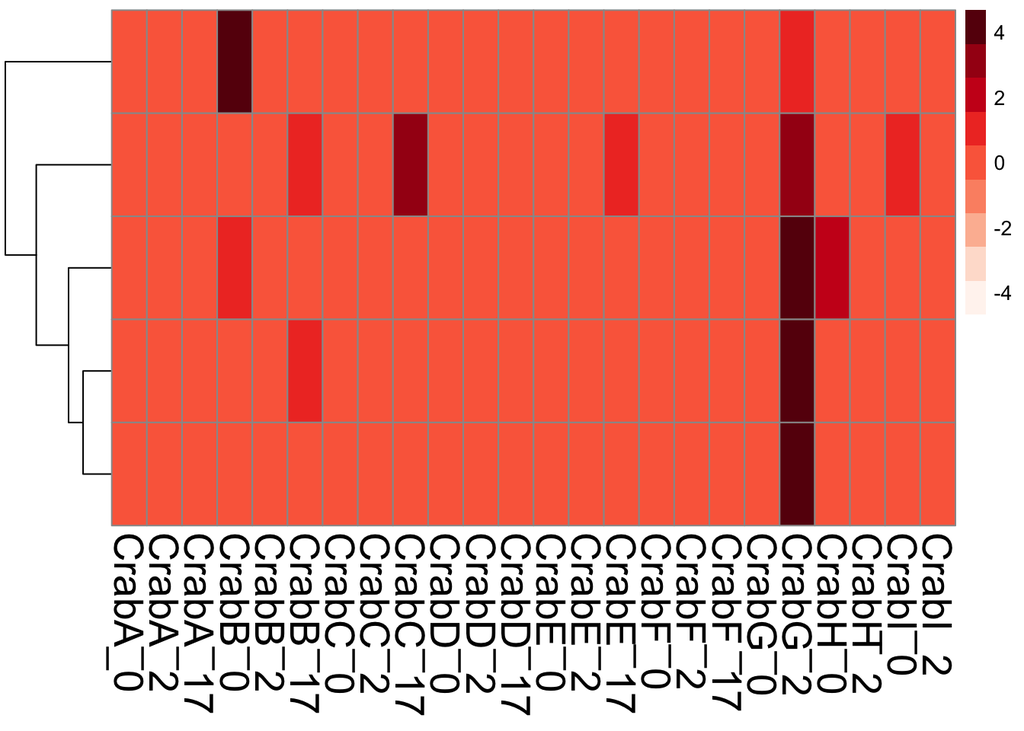

```r
pheatmap(ABCGHIdegs_all.heatmap, scale = "row", cluster_row = TRUE, cluster_cols = FALSE, clustering_distance_rows = "euclidean", clustering_method = "average", show_rownames = FALSE, show_colnames = TRUE, treeheight_col = 80, legend = TRUE, color = heatmapReds, fontsize_col = 20, fontsize_row = 12)
```

Try with color scheme RedBlue (0 value = white)

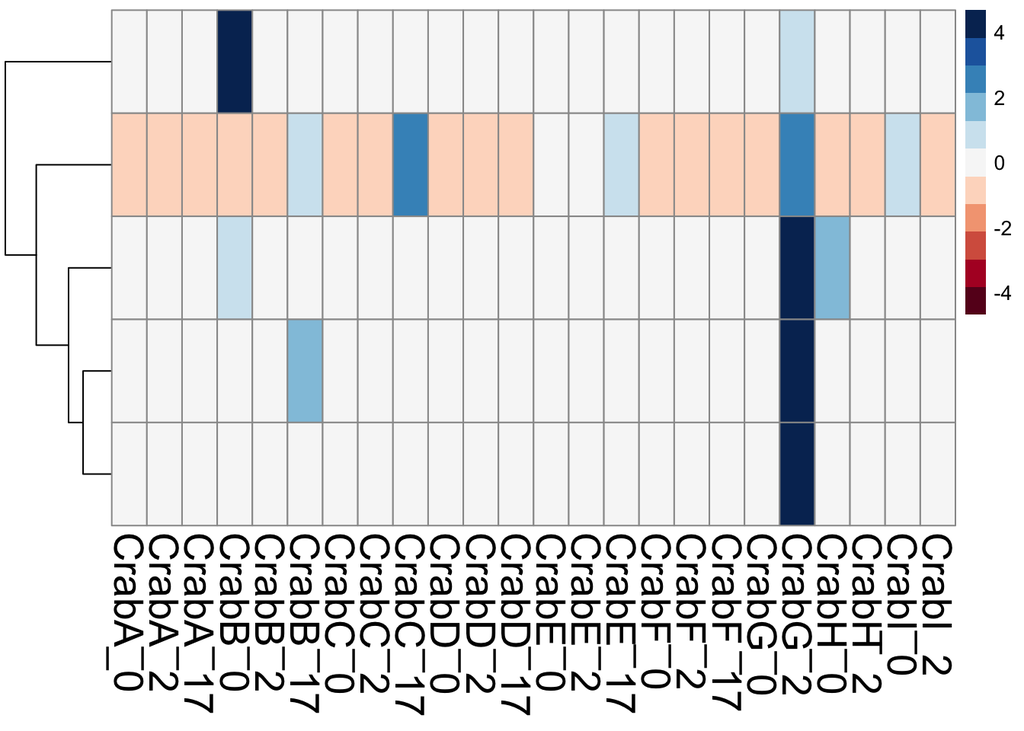

```r
pheatmap(ABCGHIdegs_all.heatmap, scale = "row", cluster_row = TRUE, cluster_cols = FALSE, clustering_distance_rows = "euclidean", clustering_method = "average", show_rownames = FALSE, show_colnames = TRUE, treeheight_col = 80, legend = TRUE, color = heatmapRedBlue, fontsize_col = 20, fontsize_row = 12)
```

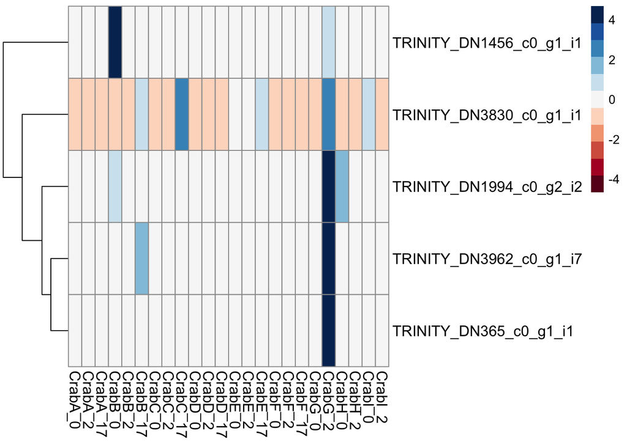

```r
pheatmap(ABCGHIdegs_all.heatmap, scale = "row", cluster_row = TRUE, cluster_cols = FALSE, clustering_distance_rows = "euclidean", clustering_method = "average", show_rownames = TRUE, show_colnames = TRUE, treeheight_col = 80, legend = TRUE, color = heatmapRedBlue, fontsize_col = 12, fontsize_row = 12)
```

# Same heatmap idea, but just for samples ABC and GHI across Day 0 and day 2:

```r
abcghidegs_twodays <- select(ABCGHI_degs_counts_match, Trinity_ID, CrabA_0, CrabA_2, CrabB_0, CrabB_2, CrabC_0, CrabC_2, CrabG_0, CrabG_2, CrabH_0, CrabH_2, CrabI_0, CrabI_2)
head(abcghidegs_twodays)
```

```
##                Trinity_ID CrabA_0 CrabA_2 CrabB_0 CrabB_2 CrabC_0 CrabC_2
## 1 TRINITY_DN1994_c0_g2_i2   0.000       0  40.323       0       0       0
## 2 TRINITY_DN3962_c0_g1_i7   0.000       0   0.000       0       0       0
## 3 TRINITY_DN1456_c0_g1_i1   0.000       0 838.191       0       0       0
## 4  TRINITY_DN365_c0_g1_i1   0.694       0   0.000       0       0       0
## 5 TRINITY_DN3830_c0_g1_i1   0.000       0   0.000       0       0       0
##   CrabG_0 CrabG_2 CrabH_0 CrabH_2 CrabI_0 CrabI_2
## 1   8.712 197.278  95.808       0  18.624       0
## 2   0.000  62.175   0.000       0   0.000       0
## 3   0.000 226.162   0.000       0   0.000       0
## 4   0.000  42.887   3.482       0   0.000       0
## 5   0.000  39.247   0.000       0  12.763       0
```

Set Trinity_ID as row names:

```r
rownames(abcghidegs_twodays) <- abcghidegs_twodays$Trinity_ID #set Trinity IDs as rownames
abcghidegs_twodays.heatmap <- abcghidegs_twodays[,-1] #remove redundant column
head(abcghidegs_twodays.heatmap)
```

```
##                         CrabA_0 CrabA_2 CrabB_0 CrabB_2 CrabC_0 CrabC_2 CrabG_0
## TRINITY_DN1994_c0_g2_i2   0.000       0  40.323       0       0       0   8.712
## TRINITY_DN3962_c0_g1_i7   0.000       0   0.000       0       0       0   0.000
## TRINITY_DN1456_c0_g1_i1   0.000       0 838.191       0       0       0   0.000
## TRINITY_DN365_c0_g1_i1    0.694       0   0.000       0       0       0   0.000
## TRINITY_DN3830_c0_g1_i1   0.000       0   0.000       0       0       0   0.000
##                         CrabG_2 CrabH_0 CrabH_2 CrabI_0 CrabI_2
## TRINITY_DN1994_c0_g2_i2 197.278  95.808       0  18.624       0
## TRINITY_DN3962_c0_g1_i7  62.175   0.000       0   0.000       0
## TRINITY_DN1456_c0_g1_i1 226.162   0.000       0   0.000       0
## TRINITY_DN365_c0_g1_i1   42.887   3.482       0   0.000       0
## TRINITY_DN3830_c0_g1_i1  39.247   0.000       0  12.763       0
```

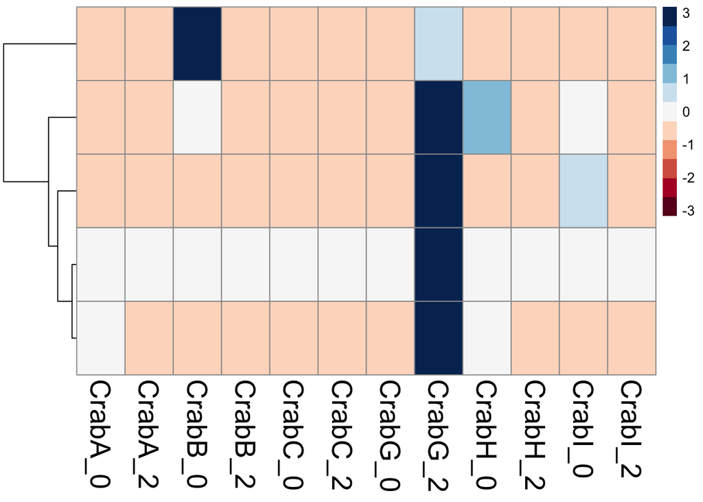

```r
pheatmap(abcghidegs_twodays.heatmap, scale = "row", cluster_row = TRUE, cluster_cols = FALSE, clustering_distance_rows = "euclidean", clustering_method = "average", show_rownames = FALSE, show_colnames = TRUE, treeheight_col = 80, legend = TRUE, color = heatmapRedBlue, fontsize_col = 20, fontsize_row = 12)
```

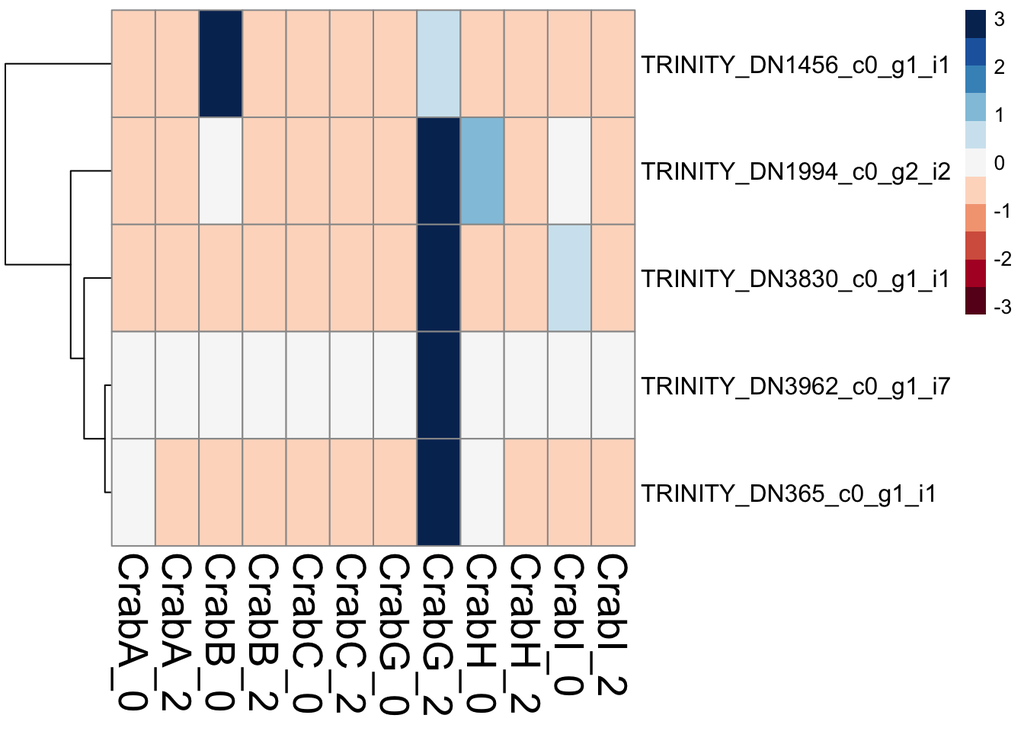

```r
pheatmap(abcghidegs_twodays.heatmap, scale = "row", cluster_row = TRUE, cluster_cols = FALSE, clustering_distance_rows = "euclidean", clustering_method = "average", show_rownames = TRUE, show_colnames = TRUE, treeheight_col = 80, legend = TRUE, color = heatmapRedBlue, fontsize_col = 20, fontsize_row = 12)
```